# Risco e Desastre nos Planos de Governo dos Candidatos a Governador (2026)

Relatório descritivo · Planos registrados no TSE, com análise de conteúdo assistida por modelos de linguagem

Autor

Afiliações

Anderson Henrique (CEM/USP e INCT QualiGov)

Centro de Estudos da Metrópole (CEM/USP), pós-doutorando com apoio da FAPESP

Instituto de Pesquisa Econômica Aplicada (Ipea), pesquisador colaborador

INCT QualiGov

Data de Publicação

29 de setembro de 2026

# Identificação

**Risco e Desastre nos Planos de Governo dos Candidatos a Governador (2026)**  
Relatório descritivo · Planos registrados no TSE, com análise de conteúdo assistida por modelos de linguagem

**Autor**  
Anderson Henrique  
Doutor em Ciência Política, Universidade Federal de Pernambuco (UFPE), 2025  
Pesquisador de pós-doutorado, Centro de Estudos da Metrópole (CEM/USP), com apoio da FAPESP  
Pesquisador colaborador, Instituto de Pesquisa Econômica Aplicada (Ipea)  
Pesquisador, Instituto Nacional de Ciência e Tecnologia QualiGov (INCT QualiGov)

**Contato e identificadores**  
andersonheri@gmail.com · ORCID 0000-0002-1842-2725 · GitHub andersonheri

**Natureza do documento**  
Relatório técnico descritivo, não revisado por pares. A classificação, as figuras e a interpretação são do autor, e as opiniões expressas não representam posição das instituições a que ele se vincula.

**Fonte dos dados**  
Portal de Dados Abertos do TSE (conjunto “Candidatos 2026”: cadastro, informações complementares e propostas de governo) e Atlas Digital de Desastres no Brasil (MIDR/S2iD). Os planos são documentos públicos registrados pelos candidatos.

**Coleta congelada em 23/09/2026** (arquivo de candidatos gerado em 23/09/2026 às 12:30:09). O registro de candidaturas e os planos podem mudar depois dessa data.

**Código e dados derivados**  
https://github.com/andersonheri/planos-governo-risco-desastre-2026

**Agradecimentos**  
A Cristiane Capuchinho (Programa de Pós-Graduação em Ciência Política, USP), pelos comentários atenciosos a uma versão anterior deste relatório, que corrigiram problemas de validade da medida e de leitura dos resultados. Os erros que restam são do autor.

**Como citar**  
HENRIQUE, A. *Risco e desastre nos planos de governo dos candidatos a governador (2026)*. Relatório descritivo. 2026. Disponível em: https://github.com/andersonheri/planos-governo-risco-desastre-2026.

# Resumo

**O que os candidatos a governador dizem, e deixam de dizer, sobre risco e desastre em seus planos de governo?** Descrevemos e comparamos o que os candidatos a governador em 2026 dizem sobre risco e desastre em seus planos de governo registrados no TSE. Analisamos os planos de 172 candidatos com candidatura deferida (coleta de 23/09/2026) por meio de um dicionário de termos e de dois modelos de linguagem de código aberto executados localmente, com o pacote acR, e medimos a presença do tema, as fases do ciclo de gestão de risco, os tipos de desastre e o grau de concretude, da menção genérica à ação com meta, prazo, indicador ou orçamento. Dos candidatos, 128 (74,4%) mencionam o tema, mas só 60 (34,9%) têm ação concreta em metade ou mais das passagens e 4 associam a ação a meta, prazo, indicador ou orçamento. Os planos falam mais de prevenção e preparação (71,5% dos candidatos) do que de resposta (34,9%) e de recuperação (24,4%). A presença do tema depende do tamanho do plano e, na extrema-esquerda, do campo político, mas a concretude não varia entre campos. Ao cruzar os planos com o histórico de desastres (S2iD, 2013 a 2025), não encontramos relação entre a intensidade dos desastres de cada estado e a concretude dos planos (correlação de Spearman de -0,02). Discutimos a diferença entre proposta, balanço e crítica e os limites de uma classificação por modelos sem validação humana. O código e os dados derivados estão em repositório aberto.

**Palavras-chave:** risco de desastre; planos de governo; eleições 2026; governadores; análise de conteúdo; modelos de linguagem.

# Abstract

**What do candidates for state governor say, and leave unsaid, about disaster risk in their government plans?** We describe and compare what candidates for state governor in Brazil’s 2026 elections say about disaster risk in the government plans registered with the electoral court (TSE). We analyze the plans of 172 candidates with approved candidacies (data frozen on 23/09/2026) using a term dictionary and two open-source language models run locally with the acR package, and we measure the presence of the topic, the phases of the risk-management cycle, the types of disaster, and the degree of concreteness, from generic mention to action with targets, deadlines, indicators, or budget. Of the candidates, 128 (74,4%) mention the topic, but only 60 (34,9%) have concrete action in half or more of their passages, and 4 tie action to a target, deadline, indicator, or budget. Plans speak more about prevention and preparedness (71,5% of candidates) than about response (34,9%) and recovery (24,4%). The presence of the topic depends on plan length and, on the far left, on political camp, but concreteness does not vary across camps. Crossing the plans with the history of disasters (S2iD, 2013 to 2025), we find no relationship between the intensity of disasters in each state and the concreteness of its plans (Spearman correlation of -0,02). We discuss the difference between proposal, balance, and criticism, and the limits of a model-based classification without human validation. Code and derived data are openly available.

**Keywords:** disaster risk; government platforms; 2026 Brazilian elections; governors; content analysis; large language models.

# 1 Introdução

Enchentes, deslizamentos, secas, queimadas e o rompimento de barragens fazem parte da rotina de vários estados brasileiros, e as enchentes de 2024 no Rio Grande do Sul tornaram a lembrança recente: os seis candidatos a governador do estado, de campos políticos diferentes, do PSTU e do PDT ao PL, citam o episódio em seus planos, e mais três candidatos de outros estados (AC, ES, RO) também o mencionam. A Lei 12.608/2012, que institui a Política Nacional de Proteção e Defesa Civil, organiza a gestão de risco em torno de prevenção, mitigação, preparação, resposta e recuperação e reparte as competências entre União, estados e municípios. Aos estados cabe, entre outras tarefas, coordenar as ações no território, mapear áreas de risco e apoiar os municípios, o que faz do governador um ator central antes, durante e depois de cada evento.

Neste relatório descrevemos e comparamos **o que os candidatos a governador dizem, e o que deixam de dizer, sobre risco e desastre** nos planos de governo registrados para as eleições de 2026. Tratamos como risco e desastre eventos naturais, climáticos e tecnológicos que ameaçam ou causam danos a pessoas, bens ou ao ambiente, como enchentes, deslizamentos, secas, incêndios florestais, rompimento de barragens e acidentes industriais; ficam de fora mitigação de emissões, emergências de saúde pública, violência e risco fiscal (definição completa em Seção 2.3).

A literatura oferece ao menos três razões para olhar esse material. A primeira é conceitual: desde os trabalhos de Quarantelli (1998) e Wisner et al. (2004), e mais recentemente Kelman (2020), entende-se que o desastre não é o evento físico em si, mas o resultado de um evento perigoso que encontra populações expostas e vulneráveis, e que a vulnerabilidade tem história, distribuição social e território (Cutter, 1996; 2011). O glossário do Escritório das Nações Unidas para Redução do Risco de Desastres (UNDRR, 2024) e o Marco de Sendai (UNDRR, 2015) traduzem essa visão em uma agenda que começa por entender o risco, passa pela governança e pelo investimento em redução de risco e chega à preparação e à reconstrução. No Brasil, essa perspectiva foi desenvolvida sobretudo pela sociologia dos desastres (Valencio, 2009; Marchezini et al., 2017) e dialoga com a leitura de Beck (2010) sobre a sociedade de risco. Um plano que fala de risco apenas como “evento climático” e um plano que fala de exposição, vulnerabilidade e prevenção estão, portanto, dizendo coisas diferentes, e o codebook que usamos tenta separar essas camadas (Seção 2).

A segunda razão é política: há evidência de que os eleitores premiam o alívio depois do desastre mais do que o investimento em prevenção (Healy e Malhotra, 2009), de que o desastre funciona como evento focalizador que abre janelas para mudança de política (Birkland, 1998; 2006) e de que a distribuição de declarações e de recursos de emergência responde a incentivos eleitorais e partidários (Reeves, 2011; Henrique e Batista, 2020). Se essas lógicas valem, é razoável esperar que os candidatos falem mais de resposta e de reconstrução do que de prevenção, e que falem mais depois do que antes de eventos marcantes. A terceira razão é a comunicação: Ewart, McLean e Ames (2016) discutem como os políticos deveriam falar antes, durante e depois dos desastres, e a literatura de gestão de crise trata a liderança pública como uma função central da resposta (Boin et al., 2005). Estudos de política de desastres tendem a se concentrar no que os governos fazem depois do evento (Sylves, 2019; Handmer e Dovers, 2007); o que os candidatos prometem antes de governar recebe menos atenção, e o plano de governo é o documento público em que essa promessa fica registrada.

Nosso objetivo é descritivo e comparativo, e se resume em uma pergunta de pesquisa: **o que os candidatos a governador dizem, e deixam de dizer, sobre risco e desastre em seus planos de governo?** Para respondê-la, medimos quantos candidatos abordam o tema, quais fases do ciclo de gestão de risco e quais tipos de desastre aparecem e com que grau de concretude. Comparamos regiões, estados, partidos e campos políticos, distinguimos o discurso sobre agenda climática em geral do discurso sobre risco e desastre, mostramos **quem fala e como fala** por meio de trechos dos próprios planos e cruzamos o que os planos citam com o histórico de desastres de cada estado. **Contribuição.** O relatório traz três contribuições. A primeira é um **retrato nacional** do que os 172 candidatos a governador dizem sobre risco e desastre antes da eleição, com casos e trechos que permitem ao leitor ver o material, e não só os indicadores. A segunda é a distinção entre **falar e prometer**, por meio de uma escala de concretude, de elementos de ancoragem (órgão, meta, prazo, indicador e orçamento) e da separação, por revisão manual, entre proposta, balanço e crítica. A terceira é um **método replicável**, em que a leitura dos planos é feita por modelos de código aberto executados localmente, com o pacote acR, com medida explícita de confiabilidade e com código e dados derivados abertos. As considerações finais retomam essas contribuições à luz dos resultados.

O relatório descreve o conteúdo dos planos, não avalia a qualidade das políticas, não prevê o comportamento de governo e não infere intenções. A ausência de menção a um tema **não significa** omissão deliberada, porque os planos variam muito de formato e de extensão (de poucas centenas a dezenas de milhares de palavras) e os candidatos podem tratar do assunto em outros espaços da campanha.

# 2 Dados e método

## 2.1 Fonte e cobertura

Os dados vêm do Portal de Dados Abertos do TSE. Usamos o cadastro dos candidatos, o arquivo de informações complementares, que traz a situação do julgamento da candidatura, e os planos de governo em PDF, disponibilizados por UF. A coleta foi **congelada em 23/09/2026**, porque o TSE atualiza os arquivos várias vezes ao dia, e cada arquivo baixado tem seu `sha256` registrado no manifesto da coleta. A situação “deferida” foi tomada do arquivo complementar, pois o cadastro principal não a traz de forma utilizável.

O universo parte dos **201 candidatos a governador** registrados nas 27 UFs. Mantivemos os 172 com candidatura **deferida** (incluindo os deferidos em prazo recursal) e, entre eles, os 172 que têm **plano de governo registrado**. Esse é o universo analisado, de **172 candidatos** no cenário principal (Tabela 1).

**Tabela 1.** Do cadastro do TSE ao universo analisado, 2026.

| Item | Valor |
| --- | --- |
| Candidaturas a governador registradas | 201 |
| Com candidatura deferida | 172 |
| Com plano de governo registrado (universo analisado) | 172 |
| Planos escaneados, lidos por reconhecimento óptico de caracteres (OCR) | 6 |
| Planos com menos de 2.000 palavras | 17 |
| Palavras por plano (mediana) | 10.488 |

Fonte: Portal de Dados Abertos do TSE (coleta de 23/09/2026).

O funil mostra o efeito de dois cortes, a candidatura deferida e a existência de plano registrado. A extensão dos planos varia muito, do 10º ao 75º percentil vai de 2.018 a 19.221 palavras, com mediana de 10.488. Adotamos como critério ex ante que planos com menos de 2.000 palavras (17 dos 172 candidatos) têm espaço insuficiente para tratar qualquer tema com profundidade comparável aos demais, e por isso aparecem sinalizados em todas as tabelas e figuras que comparam cobertura ou perfil; a Seção 13.3 testa a sensibilidade desse limiar em 1.000 e 3.000 palavras.

## 2.2 Do PDF ao texto

Convertemos os PDFs em texto. **6 planos eram documentos escaneados (imagens sem camada de texto)** e passaram por OCR com o motor Tesseract em português. Quando um candidato registrou mais de um arquivo, removemos cópias idênticas e arquivos sem conteúdo (por exemplo, capas) e unimos os demais. Em um caso (Omar Aziz, AM) analisamos o plano principal separadamente dos anexos técnicos, para que os anexos não distorcessem as comparações de extensão.

O plano típico tem **10.488 palavras** (mediana), e **17 planos têm menos de 2.000 palavras**. Nas comparações, esses planos aparecem sinalizados, porque um plano curto tem menos espaço para tratar qualquer tema.

## 2.3 Como identificamos e classificamos o tema

**Dicionário e janelas.** Um dicionário de risco e desastre, com termos como enchente, deslizamento, Defesa Civil, área de risco, evento extremo e adaptação climática, seleciona em cada plano as frases que contêm o tema. Cada frase é lida junto com a anterior e a seguinte, e o conjunto forma uma *janela* de cerca de 70 palavras em média, que é a unidade de análise. Adotamos a janela no lugar de blocos longos porque trechos extensos misturavam assuntos e geravam discordância entre os classificadores. Dentro da janela, a frase que contém o termo do dicionário, a *frase focal*, aparece marcada com » « e as vizinhas servem só de contexto. A decisão foi tomada depois de observarmos que metas e valores de frases vizinhas, muitas vezes de outros temas, elevavam indevidamente o nível de uma passagem sobre desastre (por exemplo, “500 km de pavimentação” ao lado de uma menção a alagamentos).

**O pacote acR.** A coleta do corpus, a definição dos codebooks e a codificação com modelos de linguagem passam pelo **acR**, pacote em R desenvolvido pelo autor (versão 0.3.4, licença MIT), que integra a codificação qualitativa assistida por modelos de linguagem e a análise quantitativa clássica de texto, com atenção a corpora e a codebooks político-institucionais brasileiros. Neste trabalho usamos `ac_import()` e `ac_corpus()` para montar o corpus, `ac_qual_codebook()` para declarar cada dimensão (categorias, definições e exemplos positivos e negativos) e `ac_qual_code()` para aplicar o codebook a cada janela com um modelo local. O pacote, inspirado no `quallmer` (Maerz e Benoit, 2026), está disponível em https://github.com/andersonheri/acR, e este relatório é, ao mesmo tempo, uma aplicação e um teste de seu fluxo de trabalho.

**Classificadores.** Cada janela foi classificada por modelos de linguagem que rodam localmente, o `gpt-oss-20b` e o `gemma-4-26b`, por meio do pacote `acR` e com um roteiro de codificação (codebook) que traz, para cada categoria, definição, exemplos positivos e negativos. O `gpt-oss` classificou todas as janelas e sustenta o cenário principal. O `gemma` classificou a relevância de todas as janelas e as demais dimensões em uma amostra aleatória de 30% das janelas relevantes, o que reduziu o tempo de processamento de cerca de 40 para 17 horas. O codebook tem cinco dimensões, e os quadros a seguir trazem, para cada categoria, a definição resumida e um exemplo real, extraído dos planos. As definições completas de ameaça e de ancoragem estão no Anexo E.

*Relevância.* A primeira dimensão decide se a janela trata de risco e desastre, de agenda climática geral ou de outro assunto. Uma regra de decisão explícita, aplicada em ordem, foi necessária porque, sem ela, o `gpt-oss` ignorava a definição e rebaixava para “agenda climática” passagens que traziam menção breve a enchente ou seca. Pela regra, qualquer menção a risco climático, evento extremo, Defesa Civil, desastre ou a um tipo de desastre torna a janela relevante, mesmo que breve, em lista ou genérica, e a agenda climática geral só se aplica quando nenhuma dessas ideias aparece.

**Quadro 1.** Codebook, dimensão relevância: definição e exemplo real de cada categoria.

| Categoria | Definição | Exemplo real |
| --- | --- | --- |
| Relevante | Menção explícita, ainda que breve, a desastre, risco ou evento extremo (enchente, deslizamento, seca, queimada, rompimento de barragem), à Defesa Civil no contexto de risco, a ações de prevenção, prep… | “Nosso propósito: fortalecer São Paulo diante dos eventos climáticos extremos, promovendo resiliência às secas, enchentes e incêndios, com segurança hídrica, rios revitalizados, mais áreas verdes [...… |
| Agenda climática geral | Menciona mudança ou emergência climática, transição ecológica, economia verde ou resiliência climática de forma geral, sem referir evento extremo, desastre, risco ou vulnerabilidade e sem adaptação ex… | “Revisar e atualizar o Plano Estadual de Mudanças Climáticas e a Política Estadual de Enfrentamento das Mudanças Climáticas, alinhando-os ao Plano Nacional sobre Mudança do Clima e estabelecendo prior… |
| Não relevante | Usa o termo de risco em outro sentido (fiscal, social, de corrupção), trata de emergência de saúde pública ou de meio ambiente sem ligação com evento perigoso nem com a agenda climática. | “A prevenção da corrupção, a gestão de riscos, a prestação de contas e o acesso público à informação serão deveres permanentes.” (Thor Dantas, PSB-AC, p. 6) |

Fonte: Codebook do estudo (versão v0.9) e planos de governo dos candidatos a governador (TSE).

Na prática, a decisão que mais pesa é a fronteira entre *relevante* e *agenda climática geral*, e é ela que a regra em ordem procura tornar explícita.

*Fase do ciclo.* Na segunda dimensão, marcamos todas as fases que o texto sustenta, sem inferir fases ausentes. Fundimos prevenção e preparação em uma categoria, por decisão nossa, porque a fronteira entre elas é tênue e o resultado interessa mais como contraste com a resposta e a recuperação. A adaptação climática só é marcada quando o texto fala explicitamente em adaptação ou em reduzir a vulnerabilidade a eventos climáticos, e mera menção a mudança climática, economia verde ou corte de emissões não conta.

**Quadro 2.** Codebook, dimensão fase do ciclo de gestão de risco: definição e exemplo real de cada categoria. O codebook tem uma quinta categoria, 'nenhuma fase identificável', para passagens que só citam o tema (quantificada adiante); ela não entra no quadro por não descrever uma fase do ciclo.

| Categoria | Definição | Exemplo real |
| --- | --- | --- |
| Prevenção e preparação | Tudo o que se faz antes do desastre. Prevenção reúne obras de drenagem e contenção, remoção de famílias de áreas de risco e zoneamento. Preparação reúne alertas e sirenes, planos de contingência, mape… | “Padronizar e revisar periodicamente os planos estaduais, regionais e municipais, definindo responsabilidades, níveis de acionamento, rotas de evacuação, áreas de abrigo [...] com exercícios simulados… |
| Resposta | Ação durante ou logo após o desastre, como resgate, abrigos, ajuda humanitária, mobilização de bombeiros e assistência imediata às vítimas. Moradia temporária durante a emergência conta como resposta;… | “Resposta rápida e humanizada a famílias atingidas por secas, enchentes e desastres, com auxílio-moradia e ajuda humanitária;” (Alan Rick, Republicanos-AC, p. 27) |
| Recuperação e reconstrução | Volta à normalidade depois do desastre, como reconstrução de casas e infraestrutura, moradia definitiva, auxílio econômico de médio prazo e retomada da atividade das vítimas. Aluguel social com horizo… | “Instrumentos de fomento como o Fundopem-RS viabilizaram mais de R$ 6 bilhões em investimentos produtivos e contribuíram para a geração e preservação de milhares de empregos, inclusive durante o proce… |
| Adaptação climática | Ações que citam a mudança do clima ou os eventos extremos como motivo para reduzir a vulnerabilidade, como planos de adaptação e infraestrutura resiliente. Corte de emissões e agenda verde genérica nã… | “O Plano Estadual de Adaptação Climática será construído com os territórios e incorporado a todas as secretarias.” (Isael Munduruku, Rede-AM, p. 18) |

Fonte: Codebook do estudo (versão v0.9) e planos de governo dos candidatos a governador (TSE).

A fusão de prevenção e preparação simplifica a leitura, mas esconde a diferença interna entre obra e gestão, que o relatório não explora. Resposta e recuperação podem confundir-se em benefício habitacional, porque moradia temporária, aluguel social e reconstrução aparecem lado a lado nos planos; adotamos a regra de que moradia temporária durante a emergência conta como resposta, e que aluguel social com horizonte de transição, moradia definitiva e reconstrução contam como recuperação, mesmo quando o benefício começa ainda na emergência (Anexo E). Das 124 janelas relevantes marcadas como resposta, 21 (16,9%) também são recuperação, e das 81 marcadas como recuperação, 21 (25,9%) também são resposta, o que é esperado, já que o codebook permite mais de uma fase por janela; entre os dois modelos, a concordância percentual é de 93,6% em resposta e 92,3% em recuperação, na subamostra classificada por ambos.

*Tipo de ameaça.* Na terceira dimensão, o codebook lista nove tipos (enchente e alagamento, deslizamento, seca e estiagem, queimadas e incêndios, calor extremo, tempestades, erosão costeira e fluvial, barragens e mineração e acidentes tecnológicos) mais a categoria “desastres em geral”, reservada às passagens que falam de desastre sem nomear o tipo. Mais de um tipo pode ser marcado na mesma janela, e a citação só vale se for explícita. A definição e um exemplo real de cada tipo estão no Anexo E.

*Especificidade.* A quarta dimensão mede o grau de concretude, em uma escala de 0 a 4, e sustenta a distinção entre falar e prometer. O modelo julga apenas o que a frase focal propõe ou afirma sobre risco e desastre e ignora metas, prazos e valores que se refiram a outros temas. Meta, prazo, indicador ou orçamento só contam para o nível 4 se disserem respeito à própria ação de risco, e, na dúvida entre dois níveis, o modelo escolhe o menor.

**Quadro 3.** Codebook, dimensão especificidade: definição e exemplo real de cada nível.

| Categoria | Definição | Exemplo real |
| --- | --- | --- |
| 0. Menção genérica | Cita o tema sem dizer nada concreto, como um título, um slogan ou uma intenção vaga. | “Corpo de Bombeiros, Defesa Civil e proteção diante de desastres” (Alexandre Kalil, PDT-MG, p. 4) |
| 1. Diagnóstico | Descreve o problema (dados, histórico, situação) sem propor solução. | “[...] e a resposta a riscos climáticos é fragmentada entre órgãos que não compartilham dados.” (André Luis, Missão-MA, p. 16) |
| 2. Diretriz ou compromisso | Propõe um compromisso, um critério de priorização ou uma direção de política sem ação identificável. Inclui listas genéricas de investimento e a simples citação de um órgão. | “Municípios e comunidades precisarão estar mais preparados para eventos climáticos extremos.” (Marconi Perillo, PSDB-GO, p. 40) |
| 3. Ação concreta | Descreve ação, programa, obra ou instrumento identificável, cujo objeto é prevenir, preparar, responder, recuperar ou adaptar-se a risco e desastre. | “Treinar e equipar brigadas municipais de combate a incêndios florestais, incluindo o fornecimento de kits de EPIs, veículos e equipamentos, para todos os municípios.” (Rafael Fonteles, PT-PI, p. 58) |
| 4. Ação com meta, prazo, indicador ou orçamento | Ação concreta acompanhada de meta quantificada, prazo, indicador ou orçamento que se referem à própria ação de risco e desastre. Meta ou valor de outro tema não conta. | “Investimento: R$ 300-520 milhões em quatro anos para fiscalização, defesa civil, sistemas, treinamento e infraestrutura pública;” (Ben Mendes, Missão-MG, p. 70) |

Fonte: Codebook do estudo (versão v0.9) e planos de governo dos candidatos a governador (TSE).

*Ancoragem.* A quinta dimensão registra os elementos que permitem cobrar uma promessa, a saber, órgão responsável, orçamento, meta quantificada, prazo e indicador. Por serem elementos objetivos, marcados por padrões de escrita reconhecíveis (um valor em reais, um ano, o nome de um órgão), optamos por detectá-los com regras textuais aplicadas à frase focal, em vez de pedir a classificação a um modelo de linguagem (Anexo E). As regras buscam, na frase focal, referência a valor monetário ou percentual e termos como “orçamento” (elemento orçamento), números ligados a unidades como sirenes, hectares, km ou famílias (meta quantificada), anos ou expressões de prazo como “até 2027” ou “primeiro ano” (prazo), termos como “indicador” ou “monitoramento” (indicador) e nomes de órgão como secretaria, Defesa Civil ou Corpo de Bombeiros (órgão). Por lerem só a frase focal, as regras não capturam um valor, prazo ou órgão que apareça na frase vizinha, o que torna os percentuais de ancoragem conservadores (Seção 13.3).

**Definição de risco e desastre.** Adotamos o conceito da Defesa Civil brasileira (Lei 12.608/2012), que trata risco e desastre como eventos naturais, climáticos ou tecnológicos, ou a probabilidade de ocorrerem, que causam danos a pessoas, bens ou ao ambiente. Ficam de fora mitigação de emissões, emergências de saúde pública, violência e risco fiscal. As menções à **agenda climática geral** (por exemplo, “enfrentar a emergência climática”) sem referência a evento extremo, risco ou vulnerabilidade são contadas à parte.

## 2.4 Perfil do candidato

Para resumir cada plano, alocamos o candidato ao **maior degrau alcançado**, dentre cinco (Quadro 4).

**Quadro 4.** Perfil do candidato em cinco degraus, do menos ao mais concreto.

| Degrau | Definição |
| --- | --- |
| 1. Sem menção | Nenhuma passagem sobre risco, desastre ou agenda climática. |
| 2. Só agenda climática geral | Só fala de mudança ou emergência climática em geral, sem risco, desastre ou adaptação explícita. |
| 3. Menciona risco e desastre | Ao menos uma passagem sobre risco ou desastre, mas em menos da metade delas há ação identificável (predominam menções, diagnósticos e diretrizes). |
| 4. Propõe ação concreta | Em metade ou mais das passagens sobre o tema há ação, programa, obra ou instrumento identificável sobre risco e desastre. |
| 5. Ação com meta, prazo ou orçamento | Além da predominância de ações, ao menos uma passagem associa a ação de risco a meta quantificada, prazo, indicador ou orçamento. |

Fonte: Elaboração própria.

**Por que a proporção e não o máximo?** Um plano longo tem mais passagens sobre o tema e, por isso, mais chances de conter ao menos uma com ação concreta. Se o perfil usasse o máximo entre as passagens, ele cresceria com o tamanho do plano, e 100% dos candidatos com mais de dez passagens relevantes teriam alguma passagem concreta, contra 63% dos que têm uma ou duas. Por isso o degrau de ação concreta exige que **metade ou mais das passagens relevantes** do candidato tragam ação, uma medida que não depende do número de passagens. Com uma ou duas passagens o percentual é instável, e esses candidatos aparecem sinalizados nas tabelas.

## 2.5 Revisão manual da ação com meta

Como o nível 4 sustenta o degrau mais alto do perfil e é o mais sujeito a erro, lemos uma a uma as 14 passagens que o modelo classificou nesse nível (`config/revisao_manual.csv`). Mantivemos 8 e rebaixamos 6, sendo 4 para o nível 1, por serem balanço do que já foi feito ou crítica a programa do governo, e não proposta do candidato, e 2 para o nível 3, por trazerem compromisso sem meta, prazo ou valor. Com isso, o degrau 5 do perfil caiu de 6 para 4 candidatos e o degrau 4 subiu de 54 para 56. A concordância entre modelos que apresentamos na Seção 12 usa os rótulos originais, anteriores à revisão.

## 2.6 Confiabilidade dos rótulos

Não houve codificação humana de referência. A confiabilidade é medida pela **concordância entre os dois modelos** sobre as mesmas janelas, e isso mede *consistência*, e não *acerto*. Onde os modelos discordam, apresentamos os resultados em três cenários, o **principal** (`gpt-oss`), o **conservador** (só o que os dois modelos consideram relevante) e o **amplo** (o que ao menos um considera). As medidas e os resultados por variável estão na Seção 12. A figura a seguir antecipa o resultado principal, com a concordância entre os dois modelos em cada categoria classificada, medida pelo alfa de Krippendorff.

**Figura 1.** Concordância entre os dois modelos em cada categoria classificada (alfa de Krippendorff), 2026.

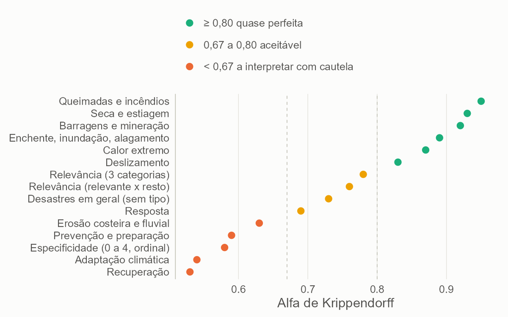

Fonte: Elaboração própria, com base na classificação pelo gpt-oss-20b e pelo gemma-4-26b.

As categorias mais consistentes são os tipos de ameaça específicos, como queimadas, seca e enchente, e as menos consistentes são a especificidade e as fases de recuperação e de adaptação. A leitura das linhas tracejadas (0,67 e 0,80) e o significado de cada medida estão na Seção 12.

## 2.7 Outras variáveis e limitações de coleta

- A exposição a desastres vem do Atlas Digital de Desastres no Brasil (Ministério da Integração e do Desenvolvimento Regional, com base no S2iD), com registros de 2013 a 2025, e mede os desastres registrados pelos municípios, e não o risco físico.
- O campo político do partido segue a classificação de Bolognesi, Ribeiro e Codato (2023), em sete categorias, agregadas por nós em cinco grupos. Partidos renomeados foram associados aos seus antecessores. UP (extrema-esquerda), Missão e PRD (extrema-direita) e Democrata e União Brasil (direita) foram classificados por nós, por terem sido criados ou fundidos depois da pesquisa que fundamenta o artigo, e o PSD segue o artigo (direita) (Seção 10 e Anexo C).
- O dado aberto não traz a condição de candidato à reeleição. Usamos como aproximação a ocupação declarada ao TSE (“governador”), que também captura vices que assumiram o cargo (18 candidatos).
- A situação da candidatura muda ao longo da campanha, e os resultados refletem o estado de 23/09/2026.
- Planos escaneados dependem da qualidade do OCR.

# 3 Panorama: quantos candidatos abordam risco e desastre

Dos **172 candidatos** analisados, **128 (74,4%)** mencionam risco ou desastre em algum ponto do plano, **3** falam apenas de agenda climática geral e **41** não têm nenhuma menção ao tema. **60 candidatos (34,9%)** têm ação concreta em metade ou mais de suas passagens sobre o tema, e **4 (2,3%)** associam a ação a meta, prazo, indicador ou orçamento.

**Figura 2.** Maior nível de tratamento de risco e desastre por candidato, 2026.

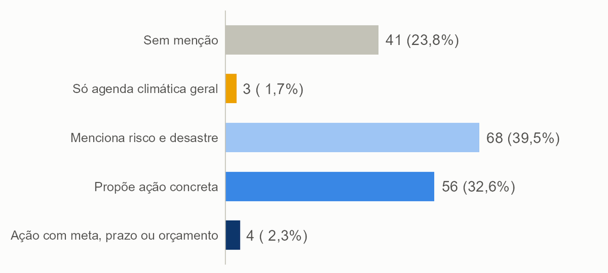

Fonte: Planos de governo dos candidatos a governador (TSE, coleta de 23/09/2026); classificação por modelos de linguagem (gpt-oss-20b e gemma-4-26b) e dicionário, com o pacote acR.

O quadro não é polarizado entre quem trata e quem ignora o tema. Três em cada quatro candidatos (74,4%) mencionam risco e desastre, presença que cai para 63,4% (109 candidatos) sob um critério mais exigente, de ao menos duas janelas relevantes em vez de uma. A presença também varia por campo político, de 50,9% a 100,0% (entre 6 e 80 candidatos por campo), e por UF, de 50,0% a 100,0% (entre 4 e 10 candidatos por UF, Seção 13.3 sobre a leitura de UFs com poucos casos). O degrau mais numeroso, com **68 candidatos**, é o das menções, diagnósticos e diretrizes, em que a ação concreta não predomina no plano. Só 60 candidatos (34,9%) têm ação concreta em metade ou mais das passagens, e apenas 4 associam essa ação a meta, prazo, indicador ou orçamento. Em resumo, o tema está amplamente presente como *menção*, com heterogeneidade relevante entre campos e estados, e é raro como *compromisso verificável* (Figura 2).

Como os modelos podem discordar nos casos de fronteira, apresentamos o resultado em três cenários (Tabela 2). A presença do tema varia pouco entre eles, o que indica que o resultado central não depende de qual modelo se adote.

**Tabela 2.** Presença do tema em três cenários de classificação, 2026.

| Cenário | Candidatos | Com menção | % com menção | % com ação concreta | Passagens relevantes |
| --- | --- | --- | --- | --- | --- |
| principal (gpt-oss) | 172 | 128 | 74,4 | 34,9 | 1.038 |
| conservador (ambos concordam) | 172 | 128 | 74,4 | 36,0 | 998 |
| amplo (algum modelo) | 172 | 132 | 76,7 | 34,9 | 1.131 |

Fonte: Planos de governo dos candidatos a governador (TSE, coleta de 23/09/2026); classificação por modelos de linguagem (gpt-oss-20b e gemma-4-26b) e dicionário, com o pacote acR.

Os cenários conservador e amplo deixam a presença do tema entre 74,4% e 76,7%, e é essa faixa que adotamos como resultado, com o cenário principal como referência.

# 4 O que os planos dizem

## 4.1 Fases do ciclo de gestão de risco

O ciclo tem quatro fases neste relatório, prevenção e preparação (o que se faz *antes* do desastre), resposta (durante), recuperação (depois) e adaptação climática (redução de vulnerabilidade diante de eventos climáticos). **27 candidatos (15,7%)** cobrem prevenção e preparação, resposta *e* recuperação.

**Figura 3.** Fases do ciclo de gestão de risco abordadas nos planos, 2026.

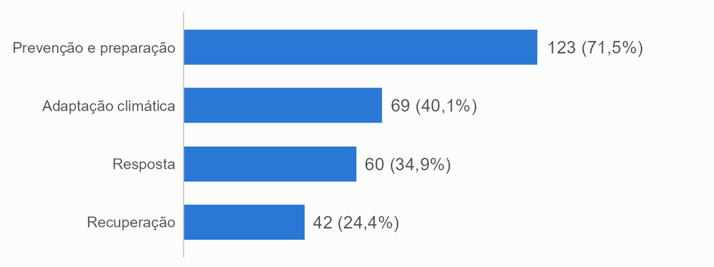

Fonte: Planos de governo dos candidatos a governador (TSE, coleta de 23/09/2026); classificação por modelos de linguagem (gpt-oss-20b e gemma-4-26b) e dicionário, com o pacote acR.

Os planos se voltam a **antecipar o desastre**. Prevenção e preparação aparecem em 71,5% dos candidatos, contra 34,9% de resposta e 24,4% de recuperação, de modo que o que acontece durante e depois do desastre está em cerca de um terço e de um quarto das candidaturas (Figura 3). A adaptação climática explícita aparece em 40,1%. Entre os 128 candidatos que mencionam o tema, 4 não descrevem nenhuma fase (só citam o assunto), 50 tratam de uma, 47 de duas e 27 das três fases do ciclo, e a maioria trata de apenas parte dele. Esse padrão contraria a conjectura, derivada de Healy e Malhotra (2009) sobre o comportamento do eleitor, de que o incentivo eleitoral favoreceria o discurso sobre o socorro e a reconstrução; tratamos a comparação como conjectura, e não como teste direto, porque os autores medem gasto público observado, não promessa de campanha, e a unidade aqui é um plano de governo estadual, um documento programático, não uma peça de campanha de rua. Uma explicação alternativa está na divisão federativa de competências (Lei 12.608/2012, Seção 1): coordenação territorial, mapeamento de áreas de risco e obras estruturais cabem sobretudo ao estado, enquanto resposta imediata e reconstrução recaem em boa parte sobre municípios e União, o que tornaria a ênfase em prevenção reflexo também do papel constitucional do governador, e não só de escolha discursiva. Os dados descrevem o que está escrito e não permitem separar essas duas explicações; a comparação com planos de governo municipais ou com o discurso de campanha nas ruas discriminaria melhor entre elas (Seção 13.3).

## 4.2 Tipos de desastre

Passando das fases para o tipo de desastre, a figura a seguir mostra a proporção de candidatos que citam cada tipo. O candidato conta uma única vez por tipo, ainda que o cite em várias passagens, e um mesmo candidato pode aparecer em vários tipos.

**Figura 4.** Tipos de desastre citados nos planos, 2026.

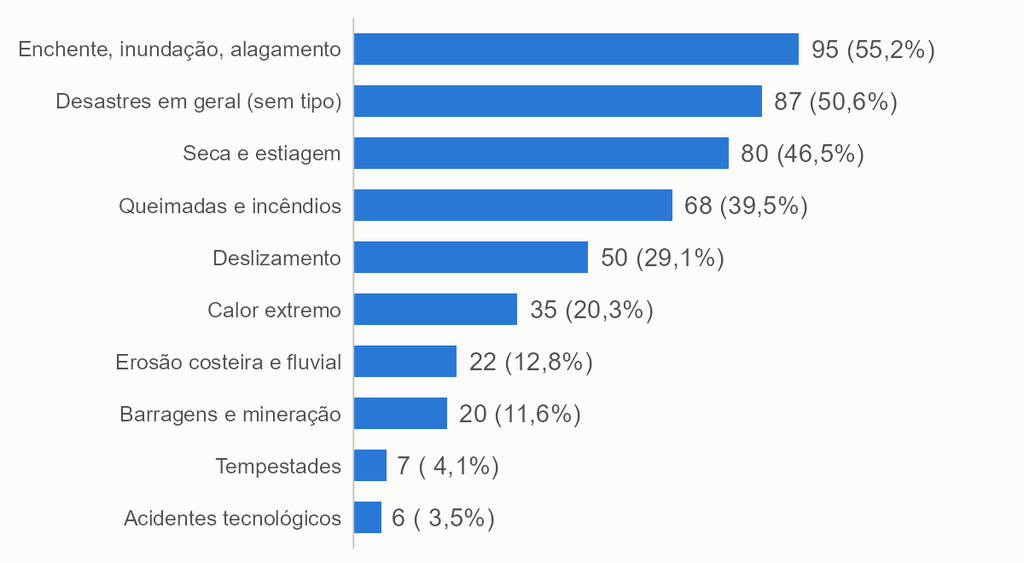

Fonte: Planos de governo dos candidatos a governador (TSE, coleta de 23/09/2026); classificação por modelos de linguagem (gpt-oss-20b e gemma-4-26b) e dicionário, com o pacote acR.

Enchentes e alagamentos são o tipo mais citado (55,2% dos candidatos), seguidos de seca e estiagem (46,5%) e de queimadas e incêndios (39,5%). Metade dos candidatos (50,6%) também fala de desastres em termos gerais, sem nomear o tipo. Os tipos mais localizados aparecem menos, como deslizamentos (29,1%), calor extremo (20,3%), erosão costeira (12,8%), barragens e mineração (11,6%), tempestades (4,1%) e acidentes tecnológicos (3,5%) (Figura 4). A Seção 9 compara esse quadro com o que cada estado de fato enfrenta.

## 4.3 A impressão digital de cada plano

Até aqui contamos candidatos por categoria. Para ver o plano inteiro de cada um, as três figuras a seguir mostram, em cada linha, um candidato que menciona o tema e, em cada coluna, uma fase do ciclo (azul) ou um tipo de desastre (verde) que o plano cita ao menos uma vez. Os candidatos estão ordenados por UF, e por nome dentro de cada UF, e a lista é dividida em três partes para que os nomes fiquem legíveis.

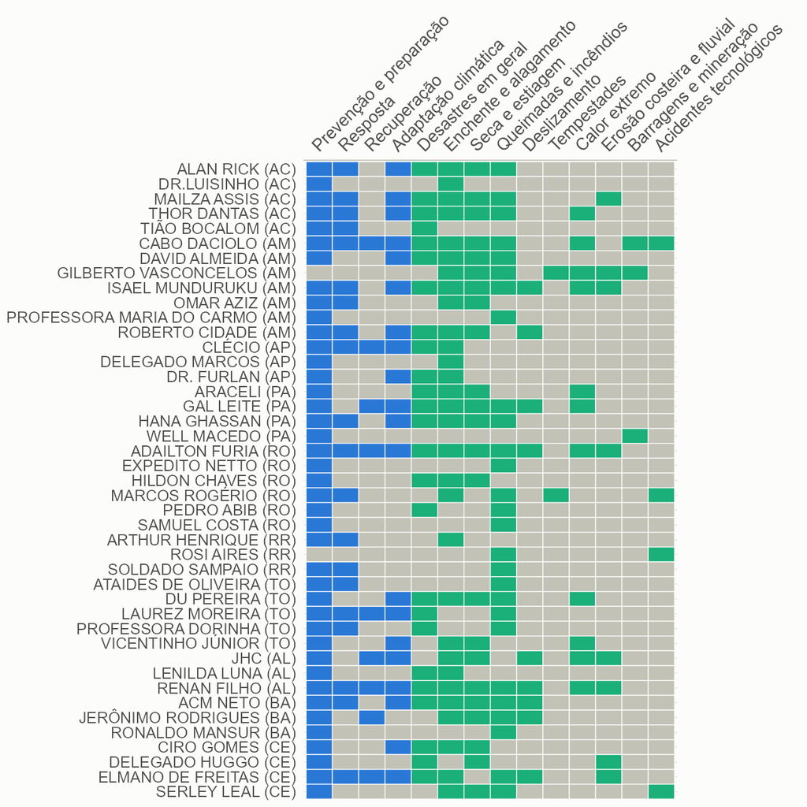

Fonte: Planos de governo dos candidatos a governador (TSE); classificação por modelos de linguagem. Azul: fase do ciclo; verde: tipo de desastre; cinza: não citado.

**Figura 6.** Fases e tipos de desastre citados por cada candidato, por UF (segunda parte da lista).

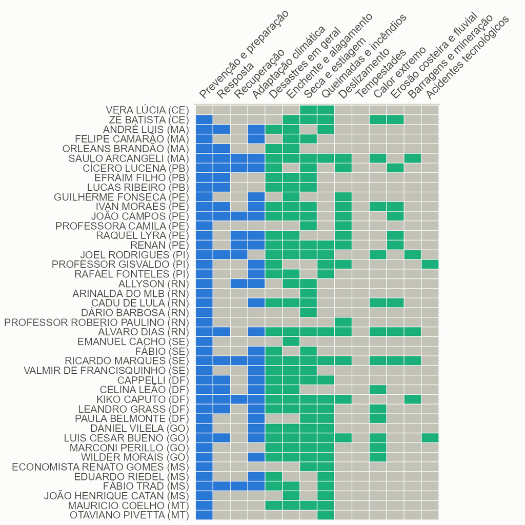

Fonte: Planos de governo dos candidatos a governador (TSE); classificação por modelos de linguagem. Azul: fase do ciclo; verde: tipo de desastre; cinza: não citado.

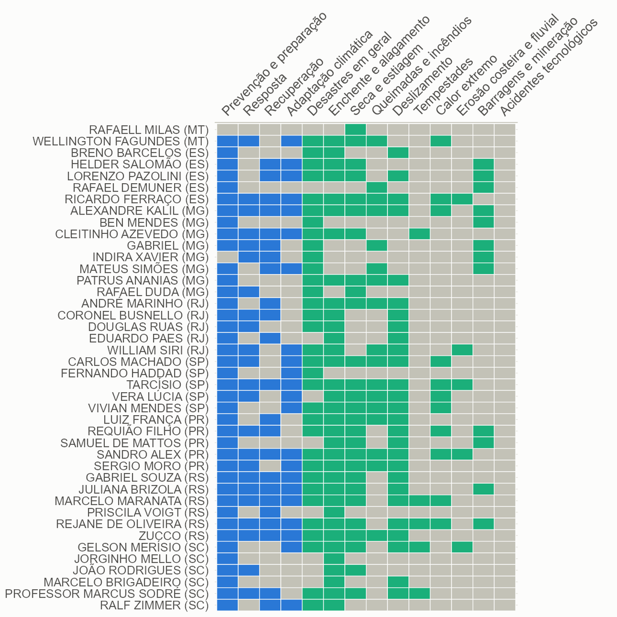

Fonte: Planos de governo dos candidatos a governador (TSE); classificação por modelos de linguagem. Azul: fase do ciclo; verde: tipo de desastre; cinza: não citado.

Como a ordem é geográfica, o que se lê na imagem é a variação dentro de cada estado, e ela é grande: em quase todas as UFs há, lado a lado, planos que cobrem grande parte das categorias e planos de uma coluna só. No conjunto, 15 candidatos citam 10 ou mais das 14 categorias, com um máximo de 12, e 1 candidatos que mencionam o tema citam uma única categoria, 0 deles apenas a prevenção e preparação, os planos “de uma nota só”. A mediana é de 6 categorias por candidato. A coluna de prevenção e preparação é a mais preenchida (123 dos 128 candidatos), e a de acidentes tecnológicos, a mais vazia, o que repete, candidato a candidato, o que as figuras anteriores mostraram no agregado (Figura 3 e Figura 4). Entre as UFs com quatro ou mais candidatos que mencionam o tema, a média de categorias citadas vai de 4 (MT) a 8.3 (RS).

# 5 Concretude: falar ou prometer

A concretude é a dimensão que separa falar de prometer. A figura a seguir distribui as passagens relevantes pelos cinco níveis de especificidade, e a unidade, agora, é a passagem, e não o candidato.

**Figura 8.** Especificidade das passagens sobre risco e desastre, 2026 (revisão manual do nível 4 incluída).

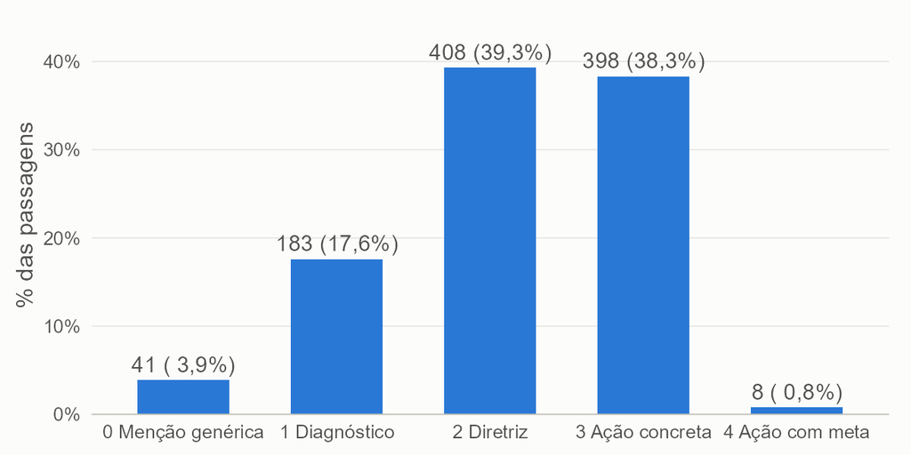

Fonte: Planos de governo dos candidatos a governador (TSE, coleta de 23/09/2026); classificação por modelos de linguagem (gpt-oss-20b e gemma-4-26b) e dicionário, com o pacote acR.

Das 1.038 passagens relevantes, 3,9% são menções genéricas, 17,6% diagnósticos (descrevem o problema), 39,3% diretrizes (compromissos sem ação identificável), 38,3% ação concreta e só 0,8% ação com meta, prazo, indicador ou orçamento (Figura 8). Cerca de 60% das passagens ficam, portanto, na descrição do problema ou em compromissos sem ação identificável e, quando há ação, ela raramente vem acompanhada de algo que permita cobrá-la. A figura seguinte mostra o que acompanha as propostas.

**Figura 9.** Elementos que acompanham as propostas de risco e desastre, entre os candidatos que mencionam o tema, 2026.

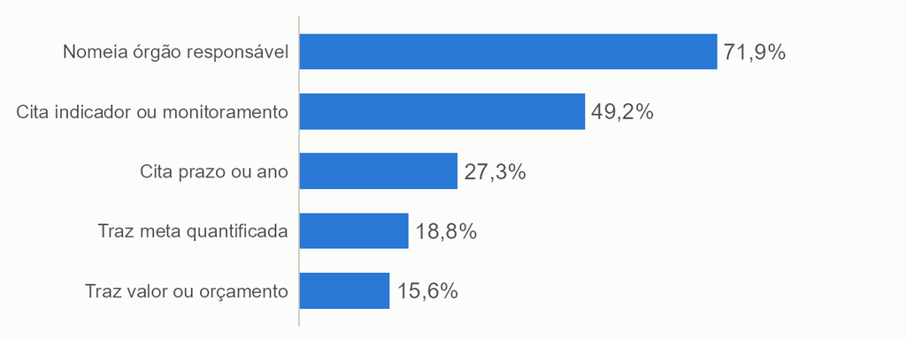

Fonte: Planos de governo dos candidatos a governador (TSE, coleta de 23/09/2026); detecção por regras textuais na frase focal.

Entre os candidatos que mencionam o tema, o elemento mais comum é o **órgão responsável** (71,9%), seguido de indicador ou monitoramento (49,2%). Prazo (27,3%), meta quantificada (18,8%) e valor ou orçamento (15,6%) são bem mais raros (Figura 9). Os elementos que permitem **cobrar** uma promessa, como meta, prazo e recurso, são, assim, os menos frequentes. Como a detecção é feita por regras e só considera a frase que contém o termo de risco, os percentuais são conservadores.

## 5.1 Quanto dinheiro se promete

O elemento que mais permite cobrar uma promessa é o valor em reais, e por isso procuramos todas as passagens sobre risco e desastre que trazem um. A tabela a seguir lista os valores encontrados e classifica cada um, porque valor em reais não é sinônimo de promessa (Tabela 3).

**Tabela 3.** Valores em reais nas passagens sobre risco e desastre, com a natureza de cada um, 2026.

| Candidato | Valor | O que é | Natureza |
| --- | --- | --- | --- |
| Tarcísio (Republicanos-SP) | R$ 25 bilhões | Até o final de 2029, em ações de adaptação e resiliência climática (drenagem, desassoreamento, reservatórios, parques, abastecimento e saneamento) | Promessa |
| Carlos Machado (PCB-SP) | R$ 1,5 bilhão | Linha de orçamento para Defesa Civil e Corpo de Bombeiros | Promessa |
| Ben Mendes (Missão-MG) | R$ 300 a 520 milhões | Em quatro anos, para fiscalização, defesa civil, sistemas, treinamento e infraestrutura pública | Promessa |
| Luis Cesar Bueno (PT-GO) | R$ 258,9 milhões (maior item) | Carteira de projetos já selecionados (drenagem, encostas, abastecimento e outros), com valores previstos nas seleções de 2023 e 2025 | Carteira de projetos |
| Raquel Lyra (PSD-PE) | R$ 80 milhões | Obra de proteção de encostas em Jardim Monte Verde, já executada | Balanço |
| Ricardo Ferraço (MDB-ES) | R$ 1,7 bilhão | Investimentos em macrodrenagem já realizados desde 2019 | Balanço |
| Rejane de Oliveira (PSTU-RS) | R$ 647 milhões | Programa A Casa é Sua – Calamidade, do governo, que entregou 196 de 2.723 moradias | Crítica |
| Rejane de Oliveira (PSTU-RS) | R$ 5,5 bilhões | Gastos climáticos do RS em 2024, segundo relatório de terceiros | Dado de terceiros |
| ACM Neto (UNIÃO-BA) | R$ 204,5 milhões e R$ 1,06 bilhão | Danos materiais e prejuízos privados dos desastres de 2024 na Bahia | Dano registrado |
| Renato Gomes (DC-MS) | R$ 150 milhões | Pacote federal usado como comparação com o prejuízo do desastre de 2020 | Comparação |
| Juliana Brizola (PDT-RS) | R$ 106,54 bilhões | Dívida do estado com a União | Outro tema |
| Gabriel Souza (MDB-RS) | R$ 6 bilhões | Investimentos produtivos viabilizados pelo Fundopem-RS | Outro tema |

Fonte: Planos de governo dos candidatos a governador (TSE); busca por expressões monetárias nas passagens relevantes e leitura de cada caso pelo autor (config/valores_reais.csv). Valores em outras partes dos planos, fora das passagens sobre o tema, não entram.

Dos 11 candidatos com valor em reais nas passagens sobre o tema, só 3 prometem gasto novo: Tarcísio (SP), com R$ 25 bilhões até 2029, Carlos Machado (SP), com R$ 1,5 bilhão para a Defesa Civil e os bombeiros, e Ben Mendes (MG), com R$ 300 a 520 milhões em quatro anos. Os demais valores são balanço do que já foi executado, crítica a programa do governo, dano registrado, comparação, carteira de projetos ou dinheiro de outro tema, como a dívida com a União. Os números não são comparáveis entre estados sem o tamanho do orçamento e da população de cada um, e só a ordem de grandeza importa: a promessa paulista é de 50 a 80 vezes a mineira. O achado principal, porém, é a escassez, já que só 3 dos 128 candidatos que mencionam o tema põem um valor em reais na própria promessa, e isso reforça a leitura de que o tema é mais mencionado do que orçado.

# 6 Falar de clima não é falar de desastre

Uma parte dos planos trata de clima como agenda geral (transição ecológica, economia verde, emergência climática) sem tratar de eventos extremos, risco ou vulnerabilidade. A distinção importa porque **3 candidatos falam só de agenda climática geral** e não aparecem como “tratando de desastre”, e porque a mesma expressão, “resiliência climática”, pode ser um slogan ou o nome de um programa de obras.

**Figura 10.** Passagens de agenda climática geral e de risco e desastre por candidato, 2026 (pontos levemente deslocados para evitar sobreposição).

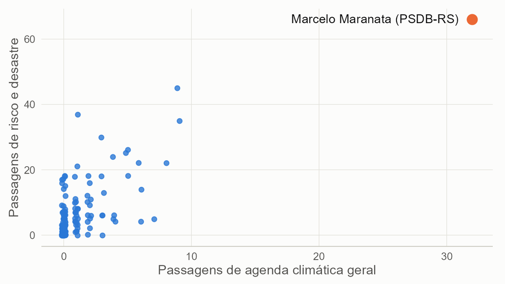

Fonte: Planos de governo dos candidatos a governador (TSE, coleta de 23/09/2026); classificação por modelos de linguagem (gpt-oss-20b e gemma-4-26b) e dicionário, com o pacote acR.

A agenda climática geral e o tratamento de desastres **andam juntos nos planos**. Dos 58 candidatos com ao menos uma passagem de agenda climática geral, 55 também têm passagens sobre risco e desastre, e só 3 falam de clima sem tratar de desastre. No conjunto, a agenda climática geral aparece em 181 passagens, contra 1.038 de risco e desastre (Figura 10). Uma ressalva é que só entram na leitura as passagens que contêm termos do dicionário de risco, que inclui mudança e emergência climática, mas não “economia verde” ou “transição ecológica” isoladas, de modo que um plano com agenda climática sem esses termos aparece como sem menção.

**O ponto isolado na figura.** O candidato rotulado no canto superior direito é Marcelo Maranata (PSDB-RS). Seu plano tem 87 páginas e 36.725 palavras e reúne 32 passagens de agenda climática geral, mais de 3 vezes o segundo maior valor do universo (9), e 66 passagens de risco e desastre, o maior número entre os 172 candidatos (o segundo é 45). Duas características do plano explicam o volume. A primeira é a estrutura: o documento organiza o programa em eixos, um deles intitulado “Desenvolvimento social e resiliência climática”, e repete o nome do eixo na apresentação, no roteiro e nas propostas detalhadas, e cada repetição de um termo do dicionário gera uma janela, de modo que o mesmo cabeçalho aparece como passagens diferentes. A segunda é a natureza das propostas: das 66 passagens relevantes, 47 (71%) são diretrizes (nível 2) e 15 são ações concretas (nível 3), o que deixa o candidato com 23% de passagens concretas, abaixo do limite de metade, e no degrau de quem “menciona risco e desastre”. Não se trata, portanto, de erro de classificação nem de um plano que ignore o tema, e sim de um plano muito longo, com muitas menções, em que predomina o compromisso genérico. Mantivemos o caso em todas as análises, e a leitura da figura não muda se ele for retirado, porque os demais candidatos ocupam a faixa de 0 a 9 passagens de agenda climática geral.

# 7 Quem fala e como fala

Até aqui descrevemos o conjunto dos candidatos. Nesta seção olhamos para quem está nas pontas da distribuição e para o modo como os planos falam do tema, com trechos dos próprios documentos. Um ponto metodológico precede a leitura dos casos: o codebook mede *o que a frase focal diz* sobre risco e desastre (nível de especificidade), mas **não distingue se a frase propõe, faz balanço ou critica**. Um plano pode dizer “executamos obras de contenção de encostas”, “os governos não fizeram a prevenção” ou “vamos construir contenção de encostas”, e as três frases têm objeto concreto. Por isso a revisão manual do nível 4 (Seção 2) foi necessária, e por isso os casos abaixo incluem exemplos de proposta, de balanço e de crítica.

## 7.1 Quem tem mais e quem tem menos ação concreta

Ordenamos os candidatos com **cinco ou mais passagens relevantes** (71 de 172) pela proporção de passagens com ação concreta, porque abaixo desse número o percentual oscila demais (Tabela 4). No topo, 6 candidatos têm 80% ou mais, e listamos cinco (empates resolvidos pelo maior número de passagens e, depois, por ordem alfabética). Na base, 6 candidatos têm 0%, e listamos os cinco com mais passagens.

**Tabela 4.** Cinco maiores e cinco menores proporções de passagens com ação concreta, entre candidatos com cinco ou mais passagens relevantes, 2026.

| Grupo | Candidato | Partido-UF | Campo | Passagens | % com ação concreta | Palavras |
| --- | --- | --- | --- | --- | --- | --- |
| Maiores | DU PEREIRA | DC-TO | Direita | 6 | 83 | 11.742 |
| Maiores | RAFAEL FONTELES* | PT-PI | Esquerda e centro-esquerda | 6 | 83 | 13.092 |
| Maiores | HILDON CHAVES | UNIÃO-RO | Direita | 5 | 80 | 31.117 |
| Maiores | JERÔNIMO RODRIGUES | PT-BA | Esquerda e centro-esquerda | 5 | 80 | 15.715 |
| Maiores | MARCOS ROGÉRIO | PL-RO | Direita | 5 | 80 | 43.784 |
| Menores | DELEGADO HUGGO | MISSÃO-CE | Extrema-direita | 7 | 0 | 12.785 |
| Menores | MARCONI PERILLO | PSDB-GO | Direita | 7 | 0 | 24.694 |
| Menores | VIVIAN MENDES | UP-SP | Extrema-esquerda | 7 | 0 | 23.300 |
| Menores | WILDER MORAIS | PL-GO | Direita | 6 | 0 | 16.716 |
| Menores | ZÉ BATISTA | PSTU-CE | Extrema-esquerda | 6 | 0 | 16.062 |

Fonte: Planos de governo dos candidatos a governador (TSE); classificação por modelos de linguagem. * Governador em exercício (aproximação pela ocupação declarada).

Os dois grupos reúnem candidatos de campos diferentes, e o tamanho do plano não os separa, com medianas de 15.715 palavras entre os maiores e de 16.716 entre os menores. O contraste está no modo de escrever: quem está no topo tende a converter o tema em programa com nome, responsável e meta, como o Piauí Preventivo, de Rafael Fonteles (PT-PI), enquanto quem está na base repete a necessidade de “prevenção” e de “preparação” sem dizer o que será feito, como veremos no caso de Marconi Perillo (PSDB-GO).

## 7.2 Os candidatos que ligam ação a meta, prazo, indicador ou orçamento

Dos 172 candidatos, apenas 4 chegam ao degrau mais alto do perfil, e vale nomeá-los, porque são o exemplo concreto do que chamamos de compromisso verificável (Tabela 5).

**Tabela 5.** Candidatos com ação concreta predominante e ao menos uma passagem com meta, prazo, indicador ou orçamento, 2026.

| Candidato | Partido-UF | Campo | Passagens | % com ação concreta | Palavras |
| --- | --- | --- | --- | --- | --- |
| PROFESSOR ROBERIO PAULINO | PSOL-RN | Extrema-esquerda | 1 | 100 | 5.644 |
| RAFAEL FONTELES* | PT-PI | Esquerda e centro-esquerda | 6 | 83 | 13.092 |
| ANDRÉ MARINHO | NOVO-RJ | Direita | 14 | 71 | 69.243 |
| TARCÍSIO* | REPUBLICANOS-SP | Direita | 13 | 62 | 21.198 |

Fonte: Planos de governo dos candidatos a governador (TSE); classificação por modelos de linguagem, com revisão manual das passagens de nível 4. * Governador em exercício (aproximação).

São 4 candidatos de 3 campos diferentes, dos quais 2 são governadores em exercício, e a mediana de extensão dos planos (17.145 palavras) se compara à mediana nacional (10.488). Como o degrau exige, além da meta, que a ação predomine nas passagens do candidato, um deles, Professor Roberio Paulino (PSOL-RN), chega ao degrau com uma única passagem, sobre um programa habitacional com meta de 50 mil moradias em que as áreas de risco são apenas critério de prioridade, e é o caso mais frágil da lista; o grupo é pequeno por construção, e a lista deve ser lida como o topo de uma escala, e não como um ranking de qualidade das políticas.

## 7.3 Proposta com meta, prazo e indicador

Os dois casos a seguir chegam ao degrau mais alto do perfil. Nos quadros, as frases em negrito são as frases focais que o modelo julgou, e `[...]` indica corte nosso, para reduzir o trecho.

**Quadro 5.** Programa com meta, indicadores e órgão nomeado (Rafael Fonteles, PT-PI).

| Candidato e página | Trecho | Classificação |
| --- | --- | --- |
| Rafael Fonteles (PT-PI), p. 60 | ODS 15 – Vida Terrestre. Programa 47 – Piauí Preventivo: Gestão de Riscos e Desastres. Meta Central: **Garantir que 100% dos municípios prioritários (aqueles com maior recorrência de desastres nos últ… | Ação com meta, prazo, indicador ou orçamento (nível 4). Prevenção e preparação. |

Fonte: Plano de governo de Rafael Fonteles (TSE). Em negrito, a frase focal; [...] indica corte nosso. Classificação pelo gpt-oss-20b, com a revisão manual quando indicado.

O Piauí Preventivo é um caso de manual do que o codebook chama de nível 4. O programa nomeia o objeto (plano de contingência e Defesa Civil municipal), define uma meta quantificada (100% dos municípios prioritários), diz como a população-alvo foi escolhida (recorrência de desastres nos últimos dez anos) e propõe indicadores de acompanhamento. É também um exemplo de por que a revisão manual importa: em outra passagem do mesmo plano, sobre apoio a planos de contingência e obras de drenagem, o modelo atribuiu o nível 4, e nós rebaixamos para o 3, porque a passagem traz compromisso sem meta, prazo ou valor.

**Quadro 6.** Proposta e balanço na mesma passagem (Tarcísio, Republicanos-SP).

| Candidato e página | Trecho | Classificação |
| --- | --- | --- |
| Tarcísio (Republicanos-SP), p. 42 | 6.1 CIDADES SP DO FUTURO **Vamos investir mais de R$ 25 bilhões, até o final de 2029, em ações de adaptação e resiliência climática - o maior plano da história, com obras e serviços estruturantes de d… | Ação com meta, prazo, indicador ou orçamento (nível 4). Prevenção e preparação, resposta, recuperação e adaptação. |

Fonte: Plano de governo de Tarcísio (TSE). Em negrito, a frase focal; [...] indica corte nosso. Classificação pelo gpt-oss-20b, com a revisão manual quando indicado.

O plano de São Paulo combina os dois registros: a primeira metade da passagem é proposta com valor e prazo (mais de R$ 25 bilhões até 2029, em adaptação e resiliência climática) e a segunda é balanço de resultados (“pela primeira vez, todos os 645 municípios contam com estruturas permanentes de Defesa Civil”). O codebook avalia a frase focal, e as frases de balanço não entraram no nível 4 desta passagem, mas o leitor deve ter em mente que a mesma página mistura o que se fará com o que já se fez.

## 7.4 Ação concreta sem meta numérica

Muitos planos chegam ao nível 3 sem chegar ao 4. Descrevem programas, obras e instrumentos identificáveis, mas não dizem quanto, quando ou com que recurso.

**Quadro 7.** Ação concreta com foco territorial e de justiça (Isael Munduruku, Rede-AM).

| Candidato e página | Trecho | Classificação |
| --- | --- | --- |
| Isael Munduruku (Rede-AM), p. 18 | AMAZONAS VIVO, JUSTO E FORTE \| PROGRAMA DE GOVERNO 2027–2030. EIXO 4 · CLIMA. **Adaptação climática com justiça territorial. Secas extremas, cheias, calor, erosão, incêndios e fumaça não atingem todo… | Ação concreta (nível 3). Prevenção e preparação e adaptação. |

Fonte: Plano de governo de Isael Munduruku (TSE). Em negrito, a frase focal; [...] indica corte nosso. Classificação pelo gpt-oss-20b, com a revisão manual quando indicado.

O plano do Amazonas nomeia instrumentos (mapa de riscos por comunidade, plano estadual de adaptação, fundo de emergência, planos regionais por tipo de evento) e um princípio de distribuição, o de que os eventos “não atingem todos da mesma maneira”. Do ponto de vista da literatura de vulnerabilidade (Cutter, 1996; Wisner et al., 2004), é um plano que trata o risco como socialmente distribuído, e não como evento físico. Do ponto de vista da cobrança, faltam meta, prazo e valor, e por isso o candidato fica no degrau 4, e não no 5.

**Quadro 8.** Diagnóstico, compromisso e ação em sequência (Zucco, PL-RS).

| Candidato e página | Trecho | Classificação |
| --- | --- | --- |
| Zucco (PL-RS), p. 13 | DEFESA CIVIL E RESILIÊNCIA CLIMÁTICA. **Os eventos extremos registrados nos últimos anos evidenciaram que o Rio Grande do Sul precisa substituir uma cultura de resposta emergencial por uma política pe… | Ação concreta (nível 3). Prevenção e preparação, recuperação e adaptação. |

Fonte: Plano de governo de Zucco (TSE). Em negrito, a frase focal; [...] indica corte nosso. Classificação pelo gpt-oss-20b, com a revisão manual quando indicado.

O plano gaúcho parte do diagnóstico das enchentes de 2024, formula o compromisso (“prevenção e resiliência climática como pilares permanentes”) e lista as ações prioritárias. É um exemplo da passagem em que os três níveis (1, 2 e 3) convivem na mesma janela, e o modelo julga o que a frase focal propõe, e não o parágrafo inteiro. Como o plano de Marcelo Maranata, também do Rio Grande do Sul, esse plano tem muitas passagens sobre o tema, o que é esperado em um estado marcado pelo desastre recente.

## 7.5 Diretriz sem ação e agenda climática geral

O degrau 3, de quem menciona o tema sem predominância de ação, é o mais numeroso, e os dois casos a seguir mostram formas diferentes de ficar nele.

**Quadro 9.** Diretriz sem ação identificável (Marconi Perillo, PSDB-GO).

| Candidato e página | Trecho | Classificação |
| --- | --- | --- |
| Marconi Perillo (PSDB-GO), p. 40 | A degradação de nascentes, mananciais e áreas ambientalmente relevantes pode comprometer a disponibilidade futura dos recursos hídricos. **Secas, ondas de calor, incêndios, chuvas intensas e outros ev… | Diretriz ou compromisso (nível 2). Prevenção e preparação. |

Fonte: Plano de governo de Marconi Perillo (TSE). Em negrito, a frase focal; [...] indica corte nosso. Classificação pelo gpt-oss-20b, com a revisão manual quando indicado.

O plano de Goiás reconhece que eventos extremos “aumentam a necessidade de prevenção e preparação” e que os municípios “precisarão estar mais preparados”, mas não diz quem fará o quê. As frases são verdadeiras e razoáveis, e são justamente o que o codebook chama de diretriz, um compromisso sem ação identificável. O candidato tem 7 passagens relevantes e nenhuma com ação concreta, mais um exemplo de que o tema aparece muito e se concretiza pouco.

**Quadro 10.** Agenda climática geral, sem risco nem desastre (Eduardo Braide, PSD-MA).

| Candidato e página | Trecho | Classificação |
| --- | --- | --- |
| Eduardo Braide (PSD-MA), p. 25 | MEIO AMBIENTE E MUDANÇAS CLIMÁTICAS. 50. **Revisar e atualizar o Plano Estadual de Mudanças Climáticas e a Política Estadual de Enfrentamento das Mudanças Climáticas, alinhando-os ao Plano Nacional so… | Agenda climática geral (fora da escala de especificidade). |

Fonte: Plano de governo de Eduardo Braide (TSE). Em negrito, a frase focal; [...] indica corte nosso. Classificação pelo gpt-oss-20b, com a revisão manual quando indicado.

O trecho do Maranhão é uma medida de gestão da política climática (revisar o plano estadual e alinhá-lo ao plano nacional), sem evento extremo, risco ou vulnerabilidade. Por isso o modelo o classificou como agenda climática geral, e não como risco e desastre, e ele não entra na escala de especificidade. Não é uma proposta ruim, mas é outra política.

## 7.6 Quando o plano faz balanço ou crítica

Há, por fim, passagens em que o nível de concretude é alto, mas a frase não é uma proposta do candidato, e foram esses dois casos que motivaram a revisão manual.

**Quadro 11.** Balanço do que já foi executado (Raquel Lyra, PSD-PE).

| Candidato e página | Trecho | Classificação |
| --- | --- | --- |
| Raquel Lyra (PSD-PE), p. 89 | [...] Na prevenção de desastres, **executamos em Jardim Monte Verde a maior obra de desenvolvimento urbano e proteção de encostas do Brasil, investindo mais de R$ 80 milhões para garantir a segurança … | Nível 4 pelo modelo, rebaixado para 1 na revisão manual (balanço do que já foi executado). |

Fonte: Plano de governo de Raquel Lyra (TSE). Em negrito, a frase focal; [...] indica corte nosso. Classificação pelo gpt-oss-20b, com a revisão manual quando indicado.

**Quadro 12.** Crítica a programa do governo (Rejane de Oliveira, PSTU-RS).

| Candidato e página | Trecho | Classificação |
| --- | --- | --- |
| Rejane de Oliveira (PSTU-RS), p. 32 | Enquanto isto, Unidades básicas de saúde, escolas e creches destruídas na enchente permanecem abandonadas. **Do programa A Casa é Sua – Calamidade – orçado em R$ 647 milhões para a construção de 2.723… | Nível 4 pelo modelo, rebaixado para 1 na revisão manual (crítica a programa do governo). |

Fonte: Plano de governo de Rejane de Oliveira (TSE). Em negrito, a frase focal; [...] indica corte nosso. Classificação pelo gpt-oss-20b, com a revisão manual quando indicado.

A passagem de Pernambuco descreve uma obra que já foi executada, com valor. A de Rio Grande do Sul, em outro polo do espectro, cita meta, valor e prazo de um programa que o governo não cumpriu. Em ambas o modelo atribuiu o nível 4, porque a frase contém valor, prazo e ação, e em ambas nós o rebaixamos para o nível 1, porque o texto não propõe nada. O caso de Rejane de Oliveira mostra ainda que, em planos de oposição, uma parte relevante do que o documento diz sobre desastre é crítica ao governo, o que também vale para o restante do plano, em que predomina o diagnóstico (nível 1).

## 7.7 O peso do balanço entre os governadores em exercício

Como um governador em exercício tem uma obra a mostrar, esperamos mais balanço nos planos dos 18 candidatos nessa condição. Para medir isso de forma aproximada, marcamos por regra textual as frases focais das passagens concretas (níveis 3 e 4) que trazem verbo de ação no pretérito (“executamos”, “o estado ampliou”, “foram distribuídas”), o que indica algo que já foi feito. A regra não distingue todos os casos, e por isso o resultado é um piso, e não uma contagem exata (Tabela 6).

**Tabela 6.** Passagens concretas com verbo de ação no pretérito, governadores em exercício e demais candidatos, 2026.

| Candidatos | Passagens concretas | Com verbo de ação no passado | % com verbo de ação no passado |
| --- | --- | --- | --- |
| Governadores em exercício (aprox.) | 71 | 6 | 8,5 |
| Demais candidatos | 335 | 3 | 0,9 |

Fonte: Planos de governo dos candidatos a governador (TSE); classificação por modelos de linguagem e regra textual sobre a frase focal (R/06_quem_fala.R).

Entre os governadores em exercício, 8,5% das passagens concretas (6 de 71) trazem verbo de ação no passado, contra 0,9% (3 de 335) entre os demais. Os números absolutos são pequenos, mas a diferença tem a direção esperada e afeta a leitura da Seção 10.4, em que os incumbentes aparecem com mais ação concreta. Parte desse resultado é, provavelmente, balanço de gestão, e não proposta, e o codebook não permite separar as duas coisas (ponto retomado nas limitações).

# 8 Por região e Unidade da Federação

Para ver se o perfil muda no território, agrupamos os candidatos nas cinco regiões. A figura a seguir mostra, para cada região, a distribuição dos candidatos pelos cinco degraus do perfil, e a tabela, logo depois, traz os indicadores correspondentes.

**Figura 11.** Perfil dos planos por região (percentual dos candidatos da região em cada degrau), 2026.

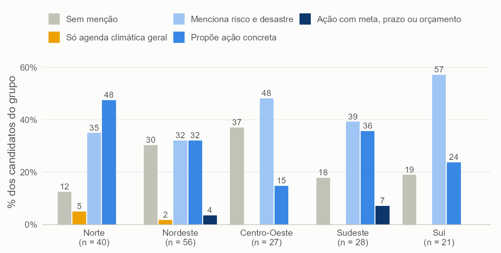

Fonte: Planos de governo dos candidatos a governador (TSE, coleta de 23/09/2026); classificação por modelos de linguagem (gpt-oss-20b e gemma-4-26b) e dicionário, com o pacote acR.

Norte (82%), Sudeste (82%) e Sul (81%) têm presença do tema em torno de 80%, e Nordeste (68%) e Centro-Oeste (63%) ficam abaixo (Figura 11 e Tabela 7). O Centro-Oeste também tem a menor proporção de candidatos com ação concreta predominante (15%, contra 48% no Norte). O **Sul se destaca** pelo ciclo completo (38% dos candidatos, mais que o dobro da média nacional de 15,7%) e pela densidade do tema (mediana de 0,51 passagens por mil palavras, contra 0,19 a 0,34 nas demais). As diferenças de tamanho de plano entre regiões são modestas (medianas de 8.346 a 12.364 palavras), e a extensão dos planos não explica esse gradiente, embora o Nordeste tenha os planos mais curtos. Com 21 a 56 candidatos por região, os percentuais devem ser lidos como tendências.

**Tabela 7.** Indicadores por região, 2026.

| Região | Candidatos | % com menção | % com ação concreta | % ciclo completo | Palavras (mediana) |
| --- | --- | --- | --- | --- | --- |
| Norte | 40 | 82,5 | 47,5 | 10,0 | 10.488 |
| Centro-Oeste | 27 | 63,0 | 14,8 | 7,4 | 12.364 |
| Nordeste | 56 | 67,9 | 35,7 | 12,5 | 8.346 |
| Sudeste | 28 | 82,1 | 42,9 | 21,4 | 11.784 |
| Sul | 21 | 81,0 | 23,8 | 38,1 | 12.295 |

Fonte: Planos de governo dos candidatos a governador (TSE, coleta de 23/09/2026); classificação por modelos de linguagem (gpt-oss-20b e gemma-4-26b) e dicionário, com o pacote acR.

Regiões com menos candidatos, como o Centro-Oeste, oscilam mais de uma eleição para outra, e a tabela traz o número de candidatos justamente para que essas diferenças sejam lidas com cautela.

Os dois mapas a seguir reduzem o perfil a um número por estado, presença do tema e ação concreta predominante, lado a lado, e servem para procurar padrões geográficos que a comparação por região poderia esconder.

**Figura 12.** Candidatos com o tema presente (esquerda) e com ação concreta predominante (direita) sobre risco e desastre, por UF, 2026.

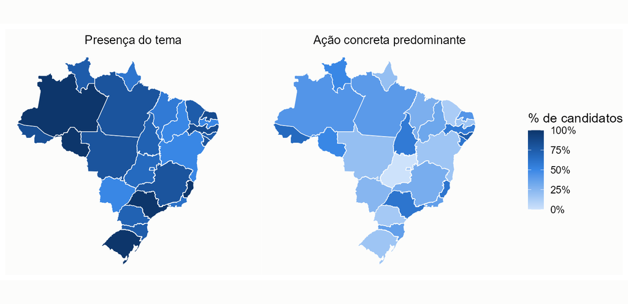

Fonte: Planos de governo dos candidatos a governador (TSE, coleta de 23/09/2026); classificação por modelos de linguagem (gpt-oss-20b e gemma-4-26b) e dicionário, com o pacote acR.

No mapa da esquerda (presença), em ES, SP, RO, AM, RS todos os candidatos mencionam o tema, e em PI, MS, PB, BA a metade ou menos. No mapa da direita (ação concreta predominante), a proporção vai de 0% (GO, 6 candidatos) a 75% (AL, 4 candidatos), sem um gradiente geográfico simples (Figura 12). Como cada estado tem de 4 a 10 candidatos, um único plano muda o percentual em 10 a 25 pontos, e o mapa é um retrato dos candidatos de 2026, e não uma medida do comportamento “do estado”. O indicador de ação concreta é ainda mais sensível para candidatos com poucas passagens relevantes: 30 dos 128 candidatos que mencionam o tema têm uma ou duas janelas relevantes (Seção 13.3), de modo que uma única passagem de nível 3 ou 4 já os classifica como “ação concreta predominante”. Os indicadores por UF estão no Anexo B.

# 9 Exposição a desastres: o que o estado enfrenta e o que os candidatos dizem

Os planos falam de desastres em geral, mas os estados enfrentam desastres diferentes. Cruzamos o que os candidatos citam com o **histórico de desastres de cada estado**, para ver se o plano fala do que o estado de fato sofre.

## 9.1 Fonte e medidas

A exposição vem do **Atlas Digital de Desastres no Brasil** (Ministério da Integração e do Desenvolvimento Regional), que consolida a base do S2iD, o sistema federal em que os municípios registram os desastres e pedem o reconhecimento de situação de emergência ou de calamidade. Usamos os registros de **2013 a 2025** (ano do evento), 43.951 registros classificados nos tipos de desastre deste estudo (98,5% dos registros do período). O Atlas já elimina duplicidades nos registros de seca e estiagem, que os municípios repetem para manter a validade dos decretos. “Chuvas intensas”, enxurradas, inundações e alagamentos foram agrupados como *enchente e alagamento*, e doenças e ondas de frio ficaram de fora.

Duas medidas resumem o alinhamento de cada estado: o **tipo principal**, que é o tipo de desastre com mais registros no estado entre 2013 e 2025 e cuja citação medimos pela proporção de candidatos, e a **cobertura da exposição**, que é, para cada candidato, a parcela dos registros do seu estado que pertence aos tipos que ele cita. Um candidato que cita apenas o tipo que responde por 80% dos registros do estado tem cobertura de 80%, e quem não cita nenhum tipo específico tem cobertura zero.

O **Distrito Federal** entra na seção com ressalva. Ele tem um único município e só 16 registros no período, de modo que o tipo principal e as proporções do DF, marcado com asterisco nos gráficos, são pouco estáveis e devem ser lidos como indicativos. A análise cobre **27 UFs e 172 candidatos**.

Antes de cruzar exposição e discurso, convém olhar o histórico. A figura a seguir mostra os registros de desastre por ano no país, com um painel para cada grupo de tipos.

**Figura 13.** Registros de desastres por ano e por tipo, Brasil, 2013 a 2025.

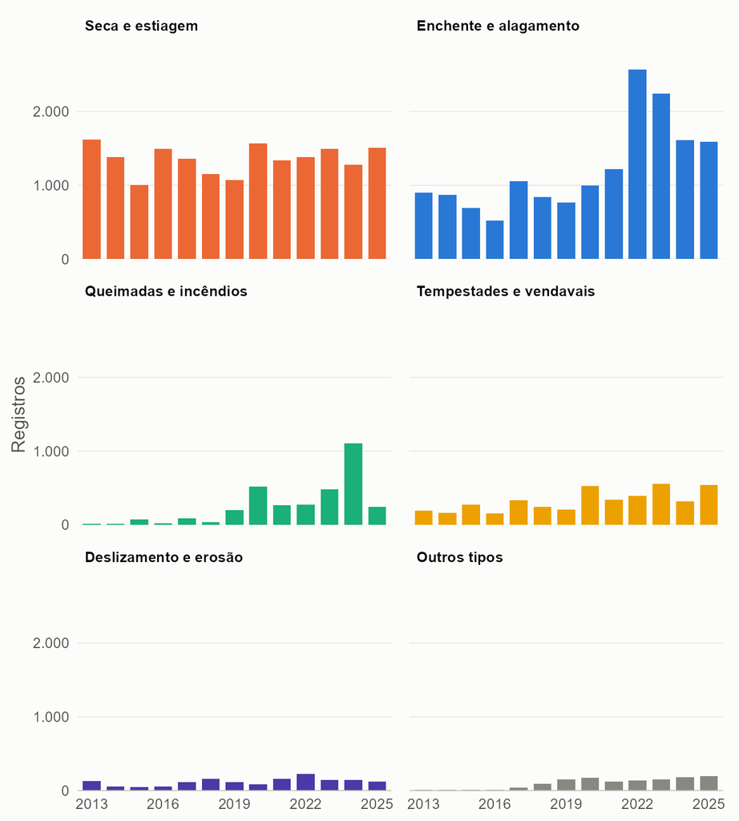

Os registros passaram de 2.860 em 2013 para 5.080 em 2023 (Figura 13). Parte desse aumento reflete o maior uso do sistema e a maior capacidade de notificar dos municípios, e não apenas mais desastres, e isso vale para toda a leitura desta seção. Os seis painéis da figura compartilham a mesma escala de eixo Y, para que a altura das barras seja comparável entre tipos, e tempestades ou queimadas não pareçam tão frequentes quanto seca ou enchente só porque cada painel teria sua própria escala.

## 9.2 O que o estado enfrenta e o que os candidatos citam

O cruzamento central da seção está no par de painéis a seguir. À esquerda, a composição dos registros de cada estado por tipo de desastre e, à direita, a proporção de candidatos do estado que citam cada tipo, com as UFs agrupadas por região.

**Figura 14.** Exposição histórica a desastres e citação dos tipos nos planos, por UF, 2013 a 2025.

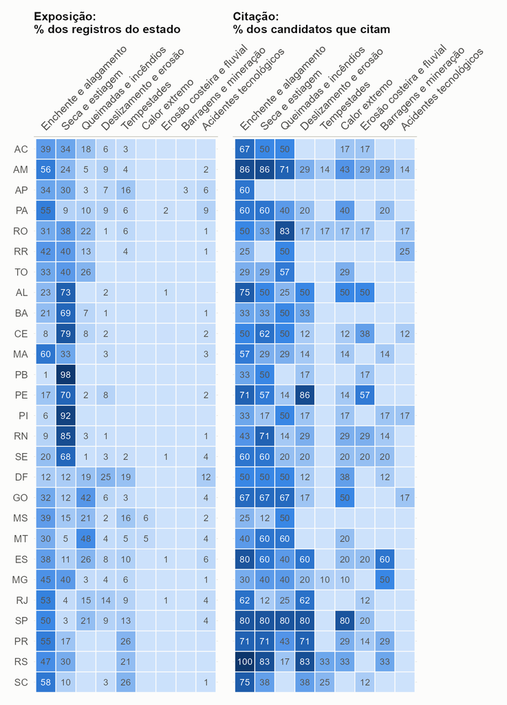

Fonte: Atlas Digital de Desastres (S2iD/MIDR) e planos de governo dos candidatos a governador (TSE).

Lidos lado a lado, os painéis mostram que a citação de enchente e alagamento é alta em quase toda parte, inclusive onde a seca domina os registros. No Piauí, a seca responde por 92% dos registros e é citada por 17% dos candidatos, e na Paraíba os valores são de 98% e 50%.

Cada estado tem a composição dos seus registros e a proporção de candidatos que citam cada tipo (Figura 14). A **enchente e o alagamento** são o principal tipo de desastre em 14 das 27 UFs, e a **seca e a estiagem**, em 10. Queimadas e incêndios lideram em 2.

## 9.3 Quem fala do principal desastre do próprio estado

Em média, **54% dos candidatos citam o principal tipo de desastre do seu estado**, e a cobertura média da exposição é de **47%**. Em 10 das 27 UFs, a metade ou menos dos candidatos cita o principal desastre do estado.

**Figura 15.** Proporção de candidatos que citam o principal tipo de desastre do próprio estado, por UF, 2013 a 2025.

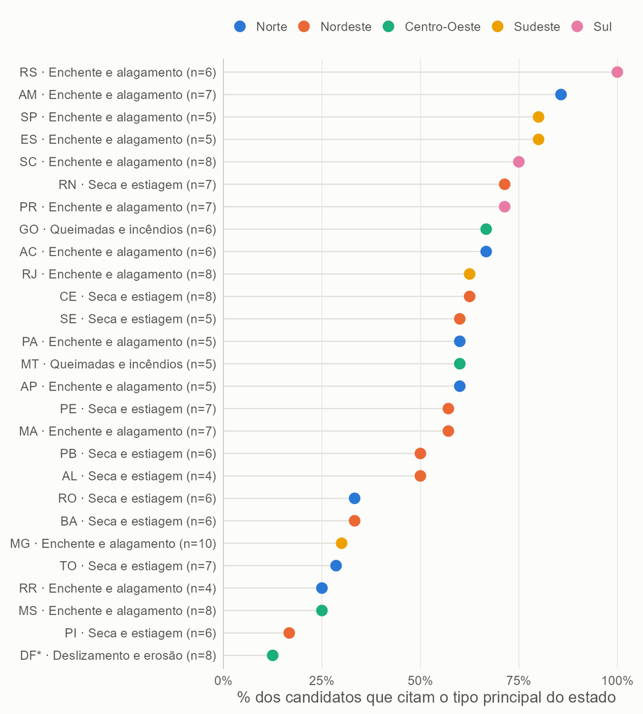

Fonte: Atlas Digital de Desastres (S2iD/MIDR) e planos de governo dos candidatos a governador (TSE).

Os estados com menor proporção são DF (12% citam deslizamento e erosão, n = 8); PI (17% citam seca e estiagem, n = 6); RR (25% citam enchente e alagamento, n = 4). No extremo oposto estão RS (100% citam enchente e alagamento, n = 6); AM ( 86% citam enchente e alagamento, n = 7); SP ( 80% citam enchente e alagamento, n = 5) (Figura 15). Com 4 a 10 candidatos por estado, cada candidato pesa de 10% a 25%, e a proporção deve ser lida como um retrato, e não como uma medida precisa. O alinhamento de cada UF está detalhado no Anexo D.

## 9.4 O mapa do descompasso

O mapa a seguir traduz o cruzamento em duas imagens lado a lado. À esquerda, a cor indica o tipo de desastre com mais registros em cada estado e, à direita, a cor indica a proporção de candidatos que citam esse mesmo tipo. O Distrito Federal, muito pequeno no mapa, aparece com asterisco (DF*), porque só tem 16 registros e o seu tipo principal é pouco estável.

**Figura 16.** O desastre que mais atinge cada estado e a proporção de candidatos que o citam, por UF, 2013 a 2025.

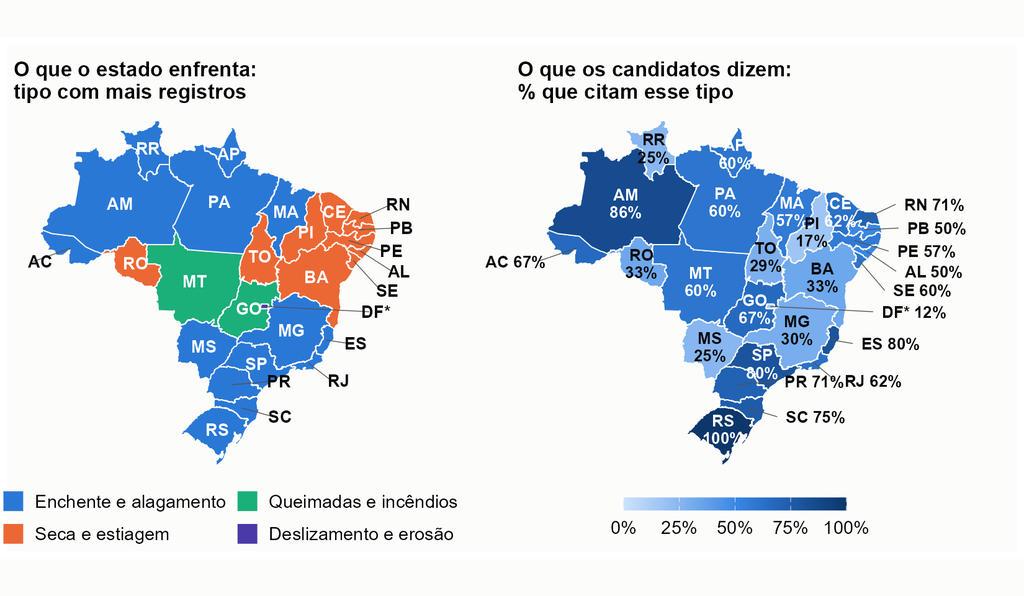

Fonte: Atlas Digital de Desastres (S2iD/MIDR, 2013 a 2025) e planos de governo dos candidatos a governador (TSE); malhas dos estados do IBGE, pelo pacote geobr. DF* tem apenas 16 registros.

A enchente e o alagamento lideram os registros em 14 UFs, a seca em 10, em sua maioria nordestinas, e as queimadas em 2, e o deslizamento lidera no Distrito Federal, cujo perfil, com só 16 registros, é o menos estável. Em nenhuma UF o tipo principal deixa de ser citado. O menor valor é o do Distrito Federal (12%, com a ressalva de que só tem 16 registros), seguido do Piauí (17%). O contraste mais nítido está no Nordeste seco. No Piauí, 92% dos registros são de seca, mas só 17% dos candidatos a citam, e na Paraíba os valores são de 98% e 50%. No extremo oposto, no Rio Grande do Sul, todos os 6 candidatos citam enchente, tipo que responde por 47% dos registros do estado. Nos estados em que a seca lidera, a mediana de candidatos que a citam é de 50%, contra 65% nos que têm a enchente à frente, o que sugere que a seca, apesar de dominar os registros, pesa menos no discurso do que a enchente (Figura 16). O padrão é compatível com a ideia de que desastres recentes e visíveis, como a enchente, entram mais nos planos do que desastres crônicos, como a estiagem, mas os dados não permitem testar essa explicação.

## 9.5 Quem mais sofre promete mais?

Por fim, cruzamos a intensidade dos desastres com a concretude dos planos para responder a uma pergunta simples: os estados que mais sofrem com desastres têm candidatos que prometem mais ação concreta? O eixo horizontal do gráfico mede os registros por município de cada estado, o que corrige o efeito do número de municípios, e o vertical, a proporção de candidatos com ação concreta predominante. O tamanho do ponto indica o número de candidatos. As linhas tracejadas dividem o gráfico em quatro quadrantes, com corte na mediana dos registros por município (8,9) e na proporção nacional de candidatos com ação concreta (34,9%).

**Figura 17.** Registros de desastre por município e proporção de candidatos com ação concreta predominante, por UF, em quatro quadrantes.

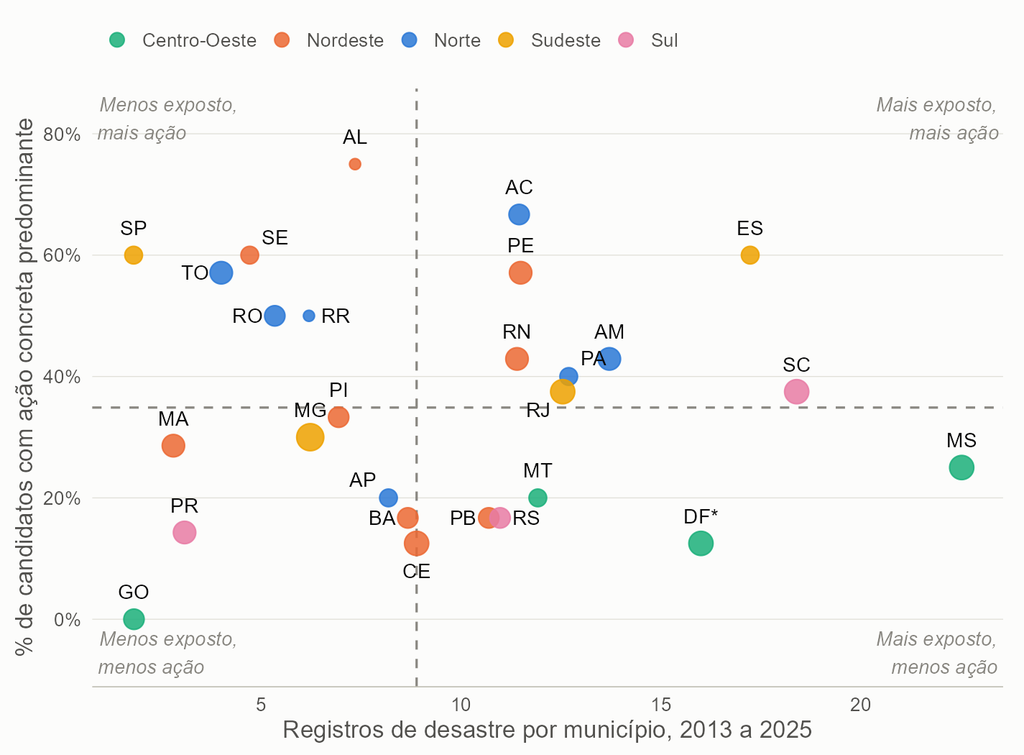

Fonte: Atlas Digital de Desastres (S2iD/MIDR, 2013 a 2025), municípios por UF (IBGE) e planos de governo dos candidatos a governador (TSE). Tamanho do ponto proporcional ao número de candidatos; linhas tracejadas na mediana dos registros por município e na proporção nacional de candidatos com ação concreta.

Os quadrantes reúnem os estados de forma quase uniforme, e isso já indica que não há um padrão dominante (Tabela 8).

**Tabela 8.** Estados por quadrante de exposição a desastres e de concretude dos planos.

| Quadrante | Estados | Nº de UFs |
| --- | --- | --- |
| Mais exposto, mais ação | AC, AM, ES, PA, PE, RJ, RN, SC | 8 |
| Menos exposto, mais ação | AL, RO, RR, SE, SP, TO | 6 |
| Mais exposto, menos ação | CE, DF, MS, MT, PB, RS | 6 |
| Menos exposto, menos ação | AP, BA, GO, MA, MG, PI, PR | 7 |

Fonte: Atlas Digital de Desastres (S2iD/MIDR, 2013 a 2025) e planos de governo dos candidatos a governador (TSE). Cortes na mediana dos registros por município e na proporção nacional de candidatos com ação concreta.

O quadrante que mais chama atenção do ponto de vista da gestão de risco é o dos estados muito expostos e com poucos candidatos com ação concreta (CE, DF, MS, MT, PB, RS), e o mais coerente com a exposição é o dos estados muito expostos e com muita ação (AC, AM, ES, PA, PE, RJ, RN, SC). Como os cortes são convenções, os estados próximos às linhas, como CE, RJ e MG, mudariam de quadrante com pequenas variações, e a leitura deve se apoiar no conjunto, e não em cada ponto.

**O que mede a correlação de Spearman.** Para resumir o gráfico em um número, usamos a correlação de Spearman, que compara a *ordem* dos estados nas duas medidas, e não os valores. Ela ordena os 27 estados do menos ao mais exposto e do menos ao mais concreto e verifica se as duas ordens caminham juntas. O coeficiente vai de −1 a +1. Perto de +1, os estados mais expostos são também os que têm mais candidatos com ação concreta; perto de −1, ocorre o contrário; perto de 0, não há relação. Como trabalha com posições, o coeficiente não supõe que a relação seja uma reta e é pouco sensível a valores extremos, como o de Mato Grosso do Sul, que tem muitos registros por município. O valor de p informa quão provável seria obter um coeficiente tão distante de zero se, na verdade, não houvesse relação, e, por convenção, valores abaixo de 0,05 são tratados como evidência de relação. Com 27 estados, só coeficientes de cerca de 0,4 ou mais, em módulo, passariam esse teste, de modo que a ausência de significância deve ser lida como ausência de padrão forte, e não como prova de que não haja relação.

**O que encontramos.** O coeficiente é de -0,02 (p = 0,935), praticamente nulo, e isso significa que conhecer a exposição de um estado quase não ajuda a prever a concretude dos seus planos. Estados com muitos registros por município, como MS, SC e ES, têm resultados muito diferentes entre si (25%, 38% e 60% de candidatos com ação concreta), e o mesmo vale para estados com poucos registros, como SP, TO e GO (60%, 57% e 0%). Em outras palavras, os dados não sugerem que quem mais sofre desastres prometa mais ação concreta, e a concretude dos planos parece responder mais ao candidato do que ao território. Com 4 a 10 candidatos por estado, cada ponto é frágil.

## 9.6 Quem não fala do desastre do próprio estado

O cruzamento pode ser lido também candidato a candidato. Dos 172 candidatos do universo, 79 não citam o principal tipo de desastre do seu estado, e a lista completa está no Anexo F. Para não tornar a leitura longa, a tabela a seguir mostra só os dez estados em que a seca lidera os registros, que são os que mais contrastam com o discurso geral sobre enchentes, e nomeia, em cada um, os candidatos que não citam a seca (Tabela 9).

**Tabela 9.** Candidatos que não citam a seca nos dez estados em que ela é o principal tipo de desastre, 2026.

| UF | Candidatos no estado | Não citam seca | Quem não cita |
| --- | --- | --- | --- |
| PI | 6 | 5 | Dra. Lúcia Santos†; Elizeu Aguiar†; Santiago Belizário†; Professor Gisvaldo; Rafael Fonteles |
| TO | 7 | 5 | Prof Witer Naves†; Siqueira Campos Jr†; Ataides De Oliveira; Laurez Moreira; Professora Dorinha |
| BA | 6 | 4 | Ariel Capistrano†; Aroldo Felix†; Maria Bona†; Ronaldo Mansur |
| RO | 6 | 4 | Expedito Netto; Marcos Rogério; Pedro Abib; Samuel Costa |
| CE | 8 | 3 | Danilo Soares†; Ieri Braga†; Elmano De Freitas |
| PB | 6 | 3 | Camilo Duarte†; Pedro Coutinho†; Yuri Ezequiel† |
| PE | 7 | 3 | Victor Assis†; Guilherme Fonseca; Raquel Lyra |
| AL | 4 | 2 | Márcio Jambo†; Lenilda Luna |
| RN | 7 | 2 | Rodrigo De Bolsonaro†; Professor Roberio Paulino |
| SE | 5 | 2 | Taty Cristina De Jesus†; Emanuel Cacho |

Fonte: Atlas Digital de Desastres (S2iD/MIDR, 2013 a 2025) e planos de governo dos candidatos a governador (TSE). Em cada UF, candidatos sem nenhuma passagem sobre risco e desastre no plano (†) vêm antes dos que mencionam o tema, mas não a seca.

Nos dez estados da seca, 33 dos 62 candidatos não citam a seca, e 17 deles, marcados com †, nem sequer mencionam o tema no plano, de modo que a ausência da seca, neles, faz parte de uma ausência maior. Os demais mencionam risco e desastre, mas falam de enchente, de queimadas ou de desastres em geral, e deixam de fora o desastre que mais atinge o próprio estado. No conjunto do país, dos 79 candidatos que não citam o principal desastre do estado, 44 não mencionam o tema, e os 35 restantes o mencionam sem nomear esse tipo. A lista é um retrato do que está escrito no plano, e não uma acusação: um candidato pode tratar da seca com outras palavras, como “crise hídrica” ou “convivência com o semiárido”, que o dicionário só captura em parte.

## 9.7 Cuidados na leitura

Os registros são **administrativos e feitos pelos municípios**, de modo que medem os desastres que geraram registro, e não o risco físico, e estados com maior capacidade de notificação e de pedir reconhecimento aparecem mais expostos. **A cobertura também depende do tamanho do plano.** Um plano curto tem menos espaço para citar vários tipos de desastre, e a cobertura mediana é de 0% na extrema-esquerda, de planos mais curtos, contra 75% na esquerda e centro-esquerda. Por isso a comparação por campo político nesta seção não deve ser lida sem considerar a extensão dos planos. Por fim, a medida é descritiva e não indica se o candidato **deveria** citar determinado tipo de desastre, e um plano pode tratar do tema de forma indireta, sem citar o tipo.

# 10 Por partido e campo político

## 10.2 Perfil dos planos por campo

A figura a seguir agrupa os candidatos nos cinco campos políticos e mostra, dentro de cada campo, a distribuição pelos cinco degraus do perfil.

**Figura 18.** Perfil dos planos por campo político (percentual dos candidatos do grupo em cada degrau), 2026.

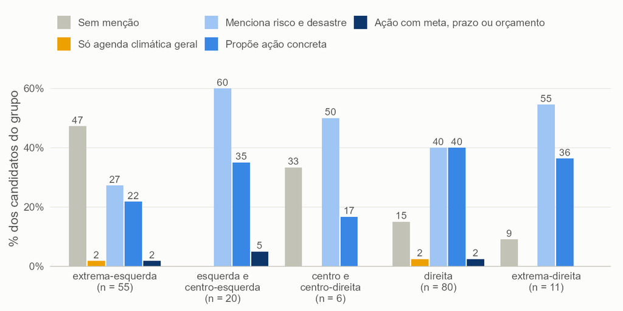

Fonte: Planos de governo dos candidatos a governador (TSE); classificação de Bolognesi, Ribeiro e Codato (2023), com grupos agregados (extrema-esquerda e extrema-direita separadas) e partidos novos classificados pelo autor.

### 10.2.1 O tamanho dos planos varia entre campos

Antes de comparar campos, um fato sobre o próprio material, que é um achado. **Os planos da extrema-esquerda são muito mais enxutos que os dos demais campos.** A mediana é de 3.802 palavras, e 13% dos planos têm menos de 2.000 palavras. Na direita, a mediana é de 11.724 palavras (12% de planos curtos), e na esquerda e centro-esquerda, de 15.403 (0%). A **extrema-direita não é mais enxuta**, pois os 11 candidatos de Missão e PRD têm mediana de 12.785 palavras e 0% de planos curtos. Esse contraste importa porque o tamanho do plano é o melhor preditor de o tema aparecer (Seção 11). A Figura 18 e a Tabela 10 mostram o perfil por campo e por categoria original.

**Tabela 10.** Tamanho do plano e tratamento do tema nas sete categorias ideológicas, 2026. Categorias com poucos candidatos (centro, n = 1) não permitem generalização.

| Categoria | Candidatos | Palavras (mediana) | % de planos curtos | % com menção | Passagens por mil palavras (mediana) | % com ação concreta |
| --- | --- | --- | --- | --- | --- | --- |
| extrema-esquerda | 55 | 3.802 | 13 | 51 | 0,06 | 24 |
| esquerda | 12 | 16.739 | 0 | 100 | 0,33 | 42 |
| centro-esquerda | 8 | 13.706 | 0 | 100 | 0,83 | 38 |
| centro | 1 | 9.704 | 0 | 100 | 1,85 | 0 |
| centro-direita | 5 | 8.577 | 0 | 60 | 0,24 | 20 |
| direita | 80 | 11.724 | 12 | 82 | 0,33 | 42 |
| extrema-direita | 11 | 12.785 | 0 | 91 | 0,25 | 36 |

Fonte: Planos de governo dos candidatos a governador (TSE); classificação de Bolognesi, Ribeiro e Codato (2023), com partidos classificados pelo autor.

Desagregada nas sete categorias, a tabela mostra que os planos curtos e a menor presença do tema se concentram na extrema-esquerda, e que a categoria de centro, com um único candidato, não permite leitura.

### 10.2.2 A diferença ideológica na presença do tema

A presença do tema não é uniforme no espectro. **Na extrema-esquerda, 51% dos candidatos mencionam risco e desastre, contra 82% na direita, 91% na extrema-direita e 100% na esquerda e centro-esquerda.** Como essa diferença se confunde com o tamanho dos planos, a testamos de duas formas, por regressão logística da presença do tema, com a direita como referência. **Sem controle pelo tamanho**, a chance de mencionar o tema na extrema-esquerda é 78% menor (razão de chances de 0,22; IC 95%: 0,10 a 0,48; p < 0,001). **Controlando pelo tamanho** (logaritmo do número de palavras), a diferença diminui, mas **não desaparece**, com razão de chances de 0,30 (IC 95%: 0,11 a 0,85; p = 0,024). Parte da menor presença se deve, portanto, aos planos mais curtos, mas não toda, e mesmo entre planos de extensão semelhante os candidatos da extrema-esquerda têm menos chance de mencionar o tema.

**A categoria, porém, não é homogênea.** Entre os partidos de extrema-esquerda, mencionam o tema UP (9 de 17), PSTU (11 de 14), PCO (0 de 11), PSOL (7 de 9), PCB (1 de 4). PSTU e PSOL estão no patamar da direita. A média baixa vem sobretudo de **PCO e UP**, que têm planos curtos (medianas de 2.577 e 3.707 palavras), e do **PCB**, cujos planos não são curtos (mediana de 9.888 palavras), mas onde apenas 1 de 4 candidatos mencionam o tema. A diferença é, portanto, de partidos específicos, e não de um comportamento comum a toda a categoria, e com 4 a 17 candidatos por partido isso deve ser lido com cautela.

**Esquerda e centro-esquerda (PT, PSB e PDT).** Todos os 20 candidatos mencionam o tema, e seus planos são os mais longos (mediana de 15.403 palavras). A distância para a direita, de 100% para 82%, está no limite da significância estatística (teste exato de Fisher, p = 0,066), e não foi possível estimá-la com controle pelo tamanho, porque a ausência de qualquer candidato sem menção impede o ajuste do modelo. **Extrema-direita** (Missão e PRD): 91% mencionam o tema, um patamar parecido com o da direita e bem acima do da extrema-esquerda, de modo que a menor presença do tema não é um traço das pontas do espectro, e sim da extrema-esquerda. O grupo de centro e centro-direita tem apenas 6 candidatos, e nada se pode concluir sobre ele.

**Quanto à concretude, não há diferença ideológica detectável.** A proporção de candidatos com ação concreta predominante é de 40% na esquerda e centro-esquerda, 42% na direita, 36% na extrema-direita e 24% na extrema-esquerda (sobre todos os candidatos de cada grupo). Entre os que mencionam o tema, nenhuma diferença entre campos é estatisticamente significativa quando se controla pelo tamanho do plano (menor valor de p entre os campos: 0,31). O que varia entre os campos é **se** o tema aparece, e não **como** ele é tratado quando aparece. Os casos da Seção 7 confirmam esse ponto, pois os planos que mais e os que menos prometem ação concreta reúnem candidatos de campos opostos.

### 10.2.3 Como interpretar

Estes resultados **descrevem o conteúdo dos planos** e não permitem atribuir causas. A menor presença do tema nos planos da extrema-esquerda pode refletir a função do plano para partidos com menor chance de governar (uma peça de posicionamento programático, mais que um programa de gestão), diferenças de estrutura e de recursos partidários ou a priorização de outras agendas, e os dados não permitem distinguir essas hipóteses. Vale registrar também que se trata de **menções** ao tema, e não de posições sobre ele, que a classificação ideológica é dos **partidos** (e não dos candidatos) e que UP, Missão, Democrata, União Brasil e PRD foram classificados por nós. Por fim, o número de candidatos por grupo é pequeno, e o tamanho do plano, muito desigual entre eles. Os indicadores por partido estão no Anexo C.

## 10.3 O vocabulário de cada campo

Para ver como os campos falam, e não só se falam, medimos em que proporção das passagens sobre risco e desastre de cada campo aparece uma série de expressões de interesse. O gráfico usa barras agrupadas, e as expressões estão ordenadas da mais à menos frequente no conjunto. O centro e a centro-direita, com poucos candidatos, ficaram de fora.

**Figura 19.** Expressões nas passagens sobre risco e desastre, por campo político (% das passagens do campo), 2026.

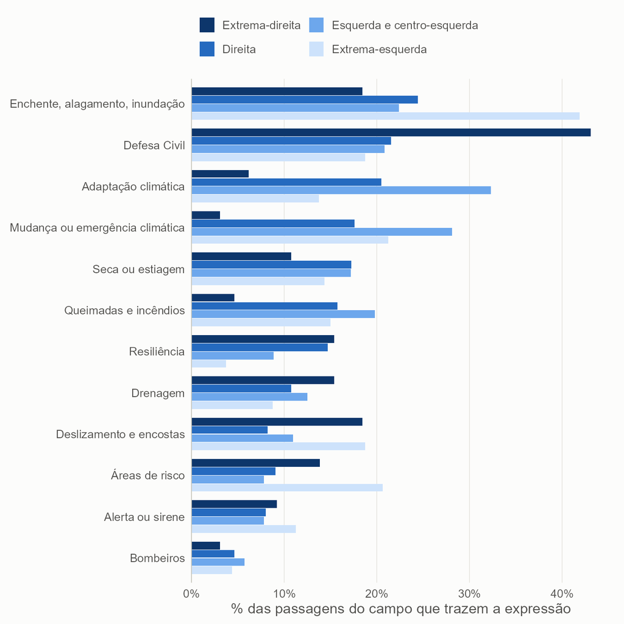

Fonte: Planos de governo dos candidatos a governador (TSE); busca por expressões nas frases focais das passagens relevantes. Nota: a nuvem de palavras comparativa do acR foi testada e descartada, porque os termos distintivos, em textos curtos, eram dominados por ruído.

## 10.4 Candidatos à reeleição

Os governadores em exercício formam um grupo à parte, porque têm gestão a mostrar. A tabela a seguir compara os 18 candidatos nessa condição com os demais.

**Tabela 11.** Governadores em exercício (ocupação declarada 'governador') e demais candidatos, 2026.

| Governador em exercício (aprox.) | Candidatos | % com menção | % com ação concreta | Palavras (mediana) |
| --- | --- | --- | --- | --- |
| Não | 154 | 71,4 | 30,5 | 10.022 |
| Sim | 18 | 100,0 | 72,2 | 14.148 |

Fonte: Planos de governo dos candidatos a governador (TSE, coleta de 23/09/2026); classificação por modelos de linguagem (gpt-oss-20b e gemma-4-26b) e dicionário, com o pacote acR.

Todos os 18 candidatos que declaram ser governadores mencionam o tema (100%), e 72% têm ação concreta predominante, contra 31% dos demais (Tabela 11). Mas seus planos também são mais longos (mediana de 14.148 palavras, contra 10.022) e, como nenhum incumbente deixa de mencionar o tema, **não é possível estimar o efeito do cargo controlando pelo tamanho do plano**. A associação não deve ser lida como efeito de já governar. Os dados não permitem separá-lo do tamanho do plano nem de outras características desses candidatos, e a variável é uma aproximação (ocupação declarada ao TSE). Há ainda um viés de medida, pois, como mostra a Seção 7, uma parte maior das passagens concretas dos incumbentes é balanço do que já foi feito, e não proposta, e o codebook não distingue as duas coisas.

# 11 Extensão do plano

**Figura 20.** Densidade de passagens sobre risco e desastre por mil palavras e tamanho do plano, 2026.

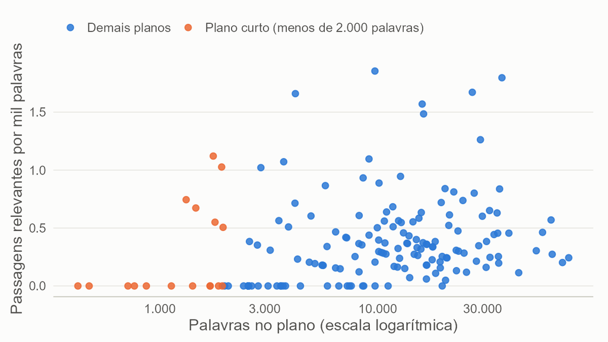

Fonte: Planos de governo dos candidatos a governador (TSE, coleta de 23/09/2026); classificação por modelos de linguagem (gpt-oss-20b e gemma-4-26b) e dicionário, com o pacote acR.

Planos curtos (17 candidatos com menos de 2.000 palavras) têm menos espaço para qualquer tema, e a densidade por mil palavras é a forma de comparar planos de tamanhos diferentes (Figura 20).

**A presença do tema depende muito do tamanho do plano.** Ela vai de 35% nos planos com menos de 5 mil palavras (52 candidatos) a 73% entre 5 e 10 mil, 96% entre 10 e 20 mil e 100% nos planos com mais de 20 mil palavras. Já entre os candidatos que mencionam o tema, a **densidade não depende do tamanho** (correlação de Spearman de -0,13), pois o tamanho do plano decide *se* o tema aparece, mas não *quão denso* ele é quando aparece. Há ainda um efeito de diluição: entre os que mencionam, a proporção com ação concreta predominante cai de 68% nos planos de 5 a 10 mil palavras para 31% nos de mais de 20 mil, porque os planos longos acumulam mais passagens genéricas. É por isso que evitamos medidas que crescem com o tamanho do plano (como “ao menos uma passagem concreta”) e sempre apresentamos o tamanho ao lado dos resultados.

**Quem são os candidatos que falam menos?** Os 17 planos com menos de 2.000 palavras estão na Tabela 12. Desses, 10 não mencionam o tema, e o restante se distribui entre a menção sem ação predominante e a ação concreta. Os partidos mais frequentes na lista são AGIR (2), DC (3), PSD (2), UP (5), e há também candidatos de partidos maiores, como Eduardo Braide e Eduardo Paes (PSD). Um plano curto não é, por si, sinal de descaso com o tema, porque alguns deles tratam do assunto de forma direta, mas reduz a chance de o tema aparecer, e por isso esses candidatos não devem ser comparados aos demais sem essa ressalva.

**Tabela 12.** Candidatos com plano de menos de 2.000 palavras, do mais curto ao mais longo, 2026.

| Candidato | Partido-UF | Palavras | Páginas | Perfil |
| --- | --- | --- | --- | --- |
| ELIZEU AGUIAR | NOVO-PI | 432 | 3 | Sem menção |
| RODRIGO DE BOLSONARO | AGIR-RN | 486 | 3 | Sem menção |
| ARIEL CAPISTRANO | DC-BA | 730 | 5 | Sem menção |
| AROLDO FELIX | UP-BA | 781 | 1 | Sem menção |
| JEFERSON BEZERRA | AGIR-MS | 885 | 3 | Sem menção |
| MÁRCIO JAMBO | DEMOCRATA-AL | 1.150 | 7 | Sem menção |
| PROFESSORA MARIA DO CARMO | PL-AM | 1.343 | 9 | Propõe ação concreta |
| EDUARDO BRAIDE | PSD-MA | 1.437 | 28 | Só agenda climática geral |
| DÁRIO BARBOSA | PSTU-RN | 1.486 | 5 | Menciona risco e desastre |
| PEDRO COUTINHO | DC-PB | 1.726 | 9 | Sem menção |
| YURI EZEQUIEL | UP-PB | 1.726 | 7 | Sem menção |
| PRISCILA VOIGT | UP-RS | 1.784 | 8 | Propõe ação concreta |
| ARINALDA DO MLB | UP-RN | 1.817 | 9 | Menciona risco e desastre |
| TATY CRISTINA DE JESUS | DC-SE | 1.885 | 11 | Sem menção |
| PROFESSORA CAMILA | UP-PE | 1.948 | 8 | Menciona risco e desastre |
| EUDO RAFFAEL | PCB-AC | 1.961 | 6 | Sem menção |
| EDUARDO PAES | PSD-RJ | 1.977 | 8 | Propõe ação concreta |

Fonte: Planos de governo dos candidatos a governador (TSE, coleta de 23/09/2026); classificação por modelos de linguagem (gpt-oss-20b e gemma-4-26b) e dicionário, com o pacote acR.

Na lista predominam partidos pequenos, mas a presença de candidatos de partidos grandes indica que a extensão do plano pode refletir uma escolha de comunicação, e não apenas o tamanho da estrutura partidária, algo que os dados não permitem afirmar.

# 12 Confiabilidade da classificação

## 12.1 O que medimos

Comparamos os rótulos dos dois modelos nas mesmas janelas. A concordância mede *consistência* entre classificadores, e não *acerto*, porque não temos codificação humana de referência. Usamos quatro medidas, que aparecem na Tabela 13.

O **acordo percentual** é a parcela de janelas em que os dois modelos deram o mesmo rótulo. É fácil de ler, mas infla quando a categoria é rara, porque dois modelos que quase nunca a marcam concordam quase sempre. O **kappa de Cohen** desconta o acordo esperado por acaso, dadas as frequências com que cada modelo marca a categoria. O **alfa de Krippendorff** faz o mesmo desconto, aceita mais de duas categorias e, na especificidade, trata os níveis como ordenados, de modo que confundir o nível 3 com o 4 pesa menos que confundir o 0 com o 4. Usamos a referência de 0,80 para conclusões firmes e de 0,67 como piso para conclusões provisórias (Krippendorff, 2018). O **AC1 de Gwet** corrige o mesmo problema de outra forma e resiste melhor ao chamado paradoxo da prevalência, situação em que o kappa cai para perto de zero apesar do acordo quase total, quando a categoria é rara (Gwet, 2014). É o que acontece com as tempestades, com 98,7% de acordo e kappa igual a zero, porque o `gpt-oss` marcou a categoria em uma janela, o `gemma` em três e os dois nunca coincidiram.

A comparação da relevância usa as 1.441 janelas classificadas pelos dois modelos. As demais dimensões usam as 311 janelas relevantes que o `gemma` classificou (a amostra de 30%), e por isso não há cenário conservador para elas.

**Tabela 13.** Concordância entre o gpt-oss-20b e o gemma-4-26b em cada variável classificada, 2026.

| Variável | Janelas | Pos. gpt-oss | Pos. gemma | Acordo (%) | Kappa | Alfa | AC1 | Leitura |
| --- | --- | --- | --- | --- | --- | --- | --- | --- |
| Relevância (3 categorias) | 1.441 | – | – | 90,7 | 0,78 | 0,78 | – | provisória |
| Relevância (relevante x resto) | 1.441 | 1038 | 1091 | 90,8 | 0,76 | 0,76 | 0,85 | provisória |
| Fase: prevenção e preparação | 311 | 225 | 179 | 81,4 | 0,60 | 0,59 | 0,66 | fraca |
| Fase: resposta | 311 | 35 | 39 | 93,6 | 0,69 | 0,69 | 0,92 | provisória |
| Fase: recuperação | 311 | 32 | 24 | 92,3 | 0,53 | 0,53 | 0,91 | fraca |
| Fase: adaptação climática | 311 | 61 | 115 | 81,4 | 0,56 | 0,54 | 0,69 | fraca |
| Ameaça: enchente e alagamento | 311 | 109 | 115 | 94,9 | 0,89 | 0,89 | 0,90 | boa |
| Ameaça: deslizamento | 311 | 38 | 42 | 96,1 | 0,83 | 0,83 | 0,95 | boa |
| Ameaça: seca e estiagem | 311 | 60 | 57 | 97,7 | 0,93 | 0,93 | 0,97 | boa |
| Ameaça: queimadas e incêndios | 311 | 48 | 48 | 98,7 | 0,95 | 0,95 | 0,98 | boa |
| Ameaça: calor extremo | 311 | 16 | 16 | 98,7 | 0,87 | 0,87 | 0,99 | boa |
| Ameaça: tempestades | 311 | 1 | 3 | 98,7 | 0,00 | 0,00 | 0,99 | poucos casos; medida instável |
| Ameaça: erosão costeira e fluvial | 311 | 16 | 15 | 96,5 | 0,63 | 0,63 | 0,96 | fraca |
| Ameaça: barragens e mineração | 311 | 7 | 6 | 99,7 | 0,92 | 0,92 | 1,00 | boa |
| Ameaça: acidentes tecnológicos | 311 | 2 | 3 | 99,0 | 0,40 | 0,40 | 0,99 | poucos casos; medida instável |
| Ameaça: desastres em geral | 311 | 107 | 107 | 87,8 | 0,73 | 0,73 | 0,78 | provisória |
| Especificidade (0 a 4, ordinal) | 311 | – | – | 64,3 | 0,56 | 0,58 | – | fraca |

Fonte: Classificação pelos dois modelos de linguagem, sobre os rótulos originais (antes da revisão manual). Leitura pelo alfa de Krippendorff (0,80 boa; 0,67 a 0,79 provisória; abaixo de 0,67 fraca); 'Pos.' são as janelas marcadas como positivas por cada modelo; 'poucos casos' indica menos de cinco positivas em ao menos um modelo.

## 12.2 O que isso significa para a leitura

A concordância é alta para os tipos de ameaça específicos (enchente, deslizamento, seca, queimadas) e aceitável para a relevância, e é menor para a fronteira entre prevenção e preparação, para a adaptação climática e para a especificidade (Figura 1). A relevância, que define se o candidato *menciona* o tema, tem alfa de 0,78, o que sustenta a presença do tema (74,4%) como o resultado mais firme do relatório. Os tipos de desastre específicos têm alfa entre 0,83 e 0,95. A **especificidade** (alfa de 0,58, abaixo do piso de 0,67) e as fases de recuperação e de adaptação climática são mais frágeis, e o degrau de “ação concreta” e as fases do ciclo devem ser lidos como **estimativas aproximadas**, e não como contagens exatas. Por isso apresentamos os resultados por candidato em três cenários e lemos os percentuais como **faixas**.

# 13 Considerações finais

Esta seção reúne o que os planos dizem, o que o relatório acrescenta e o que ele não permite concluir.

## 13.1 O que encontramos

**Os planos olham para antes do desastre.** Prevenção e preparação aparecem em 71,5% dos candidatos, resposta em 34,9% e recuperação em 24,4%, e só 27 (15,7%) cobrem as três fases. O padrão contraria a expectativa, derivada de Healy e Malhotra (2009), de que o incentivo eleitoral favoreceria o discurso sobre socorro e reconstrução, embora os dados não permitam dizer se ele reflete uma agenda de gestão ou apenas o caráter programático do documento.

**Falar de clima não é falar de desastre.** 3 candidatos falam de clima apenas como agenda geral, e a maioria dos que falam de clima também trata de desastre. O caso extremo, Marcelo Maranata (PSDB-RS), com 32 passagens de agenda climática, decorre da extensão e da estrutura do plano, e não de um erro de classificação, e não altera as conclusões.

**Quem mais e quem menos promete ação pertence a campos diferentes.** Os cinco maiores e os cinco menores percentuais de ação concreta reúnem candidatos de direita, de esquerda e de extrema-esquerda, e o tamanho do plano não os separa. O que os distingue é o modo de escrever, entre o programa com meta e indicador e a diretriz sem ação identificável. Além disso, nem toda passagem concreta é proposta: balanços e críticas ao governo apareciam entre as de nível 4, e a regra de verbos no passado indica que o balanço pesa mais entre os governadores em exercício (8,5% das passagens concretas, contra 0,9% nos demais).

**O tamanho do plano decide se o tema aparece, e o campo político, em parte.** A presença do tema vai de 35% nos planos com menos de 5 mil palavras a 100% nos de mais de 20 mil, mas, entre quem menciona, a densidade não depende do tamanho. Na extrema-esquerda, 51% dos candidatos mencionam o tema, contra 82% na direita, 91% na extrema-direita e 100% na esquerda e centro-esquerda. Os planos da extrema-esquerda são bem mais enxutos (mediana de 3.802 palavras, contra 11.724 na direita), mas a diferença de presença persiste ao controlar pelo tamanho (razão de chances de 0,30; p = 0,024) e é heterogênea entre os partidos da categoria. Na concretude, não se detecta diferença entre campos.

**O plano não acompanha o desastre que o estado sofre.** Em média, 54% dos candidatos citam o principal tipo de desastre do seu estado, e em 10 das 27 UFs a metade ou menos o faz. A seca domina os registros do Piauí e da Paraíba, mas é pouco citada, e a intensidade dos desastres de cada estado não se associa à concretude dos planos (Spearman de -0,02). Entre regiões, o Centro-Oeste e o Nordeste têm menor presença do tema, e o Sul se destaca pelo ciclo completo, mas com poucos candidatos por região e por estado essas diferenças são tendências.

## 13.2 Contribuições

**Um retrato nacional antes da eleição.** O relatório documenta, para 172 candidatos e 172 planos, o que se diz sobre risco e desastre, com trechos e casos nominais que permitem ao leitor conferir a leitura. Esse registro serve de linha de base para comparar, depois da posse, o que foi prometido e o que foi feito.

**Falar e prometer.** A escala de concretude, os elementos de ancoragem e a revisão manual separam o compromisso que se pode cobrar da menção que não se pode, e mostram que a distinção entre proposta, balanço e crítica precisa entrar nos codebooks de planos de governo.

**Um método replicável.** A leitura por modelos de código aberto executados localmente, com o pacote acR, dispensa o envio de textos a serviços externos, vem com medida explícita de confiabilidade e pode ser reaproveitada em outros cargos, eleições e temas, porque código, codebook e dados derivados estão abertos.

## 13.3 Limitações e cuidados de leitura

**Consistência não é acerto.** A classificação não foi validada por codificação humana, e a confiabilidade medida é a concordância entre dois modelos. Ela é boa para os tipos de ameaça e aceitável para a relevância (alfa de 0,78), mas fraca para a especificidade (alfa de 0,58). O degrau de ação concreta e as fases do ciclo devem ser lidos como estimativas aproximadas, e por isso apresentamos faixas, e não números exatos. A leitura de casos mostrou passagens em que o termo do dicionário aparece em contexto alheio ao tema, o que reforça a necessidade de validação humana.

**A categoria “erosão costeira e fluvial” tem ruído conhecido.** Na versão anterior do codebook a categoria cobria só erosão de costa e mar; ampliamos a definição para incluir erosão de margem de rio depois de identificar um caso de erosão fluvial (margem do rio Acre) classificado nela. Uma varredura das 41 janelas dessa categoria mostrou que a maior parte, em UFs litorâneas, de fato descreve costa, litoral ou orla, mas ao menos 5 janelas (em AC, RO e AM, todas sem litoral) e pelo menos 2 janelas adicionais em UFs litorâneas usam a palavra “erosão” de forma genérica, numa lista de riscos, sem especificar costa, rio ou encosta. O termo genérico parece atrair classificações para essa categoria além do pretendido, e o percentual de candidatos citando erosão costeira e fluvial deve ser lido como uma estimativa com limite superior de ruído, não como contagem exata.

**Prevenção sobre resposta pode refletir competência, não só discurso.** O predomínio de prevenção e preparação sobre resposta e recuperação (Seção 3) tem ao menos duas explicações que os dados não separam: uma agenda de campanha e a divisão federativa de competências, que atribui ao estado sobretudo coordenação e obras estruturais. Comparar com planos de governo municipais, onde resposta e reconstrução têm peso constitucional maior, ou com o discurso de campanha fora do plano escrito, permitiria testar as duas explicações separadamente; nenhuma das duas comparações foi feita aqui.

**“Gestão de riscos” é um termo ambíguo na regra de relevância.** A versão do codebook usada na classificação listava “gestão de riscos” como gatilho de relevância sem qualificá-lo como gestão de riscos *de desastres*, o que colide com sentidos correntes nos planos, como gestão de riscos fiscais, de corrupção ou corporativos. Das 101 janelas do corpus que contêm o termo, 47 foram marcadas como relevantes; uma leitura de amostra sugere que o modelo usou o contexto para decidir na maior parte dos casos, mas alguns falsos positivos aparentam persistir, como menções a “governança corporativa, gestão de riscos e transparência” em contexto financeiro. Qualificamos a regra para a versão v0.9 do codebook (Seção 2.3), mas não reclassificamos a base já codificada.

**Ancoragem por regras não foi validada.** Os elementos de ancoragem (órgão, orçamento, meta, prazo, indicador) são detectados por regras textuais aplicadas à frase focal (Seção 2.3), e não dispomos de um piloto comparando essas regras com a classificação por modelo de linguagem ou com uma leitura manual. Não é possível, portanto, reportar precisão e revocação das regras, e os percentuais de ancoragem devem ser lidos como estimativas conservadoras, sujeitas a falsos negativos quando o elemento aparece fora da frase focal.

**Planos curtos e o limiar de 2.000 palavras.** O limiar que sinaliza planos curtos (Seção 2) é uma convenção, e não um valor testado a priori. Refazer o corte em 1.000 palavras marca 5 planos como curtos (2,9% do total), e em 3.000 palavras marca 36 (20,9%), contra os 17 (9,9%) do limiar adotado. Em todos os cortes a presença do tema é bem mais baixa entre os planos curtos do que entre os demais, o que sustenta a direção do achado, mas a amostra de planos curtos é pequena e o percentual exato de presença entre eles varia com o limiar escolhido.

**Proposta, balanço e crítica se misturam.** O nível de especificidade mede o que a frase diz sobre risco e desastre, e não de quem é a proposta. A revisão manual corrigiu as 14 passagens de nível 4, mas os níveis 2 e 3 não foram revistos um a um. Isso pesa sobretudo nos governadores em exercício, e a comparação de concretude entre incumbentes e demais candidatos deve ser lida com essa ressalva. A regra de verbos no passado é um indicador aproximado, com números absolutos pequenos.

**Ausência de menção não é omissão.** O formato e a extensão dos planos variam de centenas a dezenas de milhares de palavras, e os candidatos podem tratar do tema em outros espaços da campanha. O tamanho do plano se associa fortemente à presença do tema, e as comparações por campo político, região e incumbência se confundem em parte com essa extensão. Quando não é possível controlá-la, como entre os incumbentes, todos com menção, a associação não deve ser lida como efeito.

**Poucos casos por estado e por partido.** Cada UF tem de 4 a 10 candidatos, e cada partido, menos ainda, de modo que um único plano altera o percentual em 10 a 25 pontos. Os mapas e as tabelas por UF são retratos dos candidatos de 2026, e não medidas do comportamento “do estado” ou “do partido”.

**Classificações do autor e aproximações.** A classificação ideológica é dos partidos, e não dos candidatos, e cinco partidos (UP, Missão, Democrata, União Brasil e PRD) foram classificados por nós, e outros foram associados a seus antecessores. A condição de candidato à reeleição é aproximada pela ocupação declarada ao TSE.

**Exposição é registro administrativo.** O Atlas Digital de Desastres reúne registros feitos pelos municípios, de modo que estados com maior capacidade de notificação aparecem mais expostos, e os registros crescem também por maior uso do sistema. A medida não é a do risco físico.

**Retrato de uma data.** Os resultados refletem o estado dos registros em 23/09/2026, e candidaturas e planos podem mudar depois dela.

## 13.4 Próximos passos

Quatro passos ampliariam a confiança e o alcance dos resultados: uma validação humana, em amostra de passagens, para medir o acerto e não só a consistência; a validação das regras de ancoragem contra uma amostra codificada manualmente (por exemplo, 100 janelas estratificadas por candidato), para estimar precisão e revocação; a codificação explícita de proposta, balanço e crítica, que resolveria a maior limitação apontada; e a comparação, depois da posse, entre o que foi prometido e o que o governo executou em prevenção, preparação e resposta.

# Transparência, replicabilidade e uso de inteligência artificial

**Replicabilidade.** O código, o codebook, as tabelas derivadas, os exemplos e este relatório estão em um repositório público, para que qualquer pessoa possa refazer a coleta, a classificação e as análises: https://github.com/andersonheri/planos-governo-risco-desastre-2026. O pipeline está em scripts numerados (`R/00` a `R/08`), cada arquivo baixado tem seu `sha256` registrado no manifesto da coleta, e os dados de origem são públicos (TSE e Atlas Digital de Desastres). A classificação por modelos de linguagem foi feita com o pacote **acR**, desenvolvido pelo autor e também aberto (https://github.com/andersonheri/acR), de modo que o fluxo de codificação pode ser reaproveitado em outros corpora e codebooks.

**Declaração sobre o uso de inteligência artificial.** Usamos inteligência artificial de duas formas, com funções e limites distintos.

*Como instrumento de medida.* Dois modelos de linguagem de código aberto, executados localmente, no computador do autor, por meio do LM Studio, aplicaram o codebook às passagens dos planos, o `gpt-oss-20b` (OpenAI) e o `gemma-4-26b` (Google), com o pacote acR. O primeiro classificou todas as passagens e sustenta o cenário principal, e o segundo classificou a relevância de todas e as demais dimensões em uma amostra aleatória de 30% das relevantes. Na classificação, nenhum texto dos planos foi enviado a serviços externos. Os PDFs escaneados foram lidos com o Tesseract (OCR), que não é um modelo generativo. Os limites dessa medida, que é consistente entre modelos, mas não foi validada por codificação humana, estão descritos na Seção 12 e nas limitações.

*Como assistente de trabalho.* O modelo Claude Sonnet 5 (Anthropic), usado por meio do Claude Code, apoiou a escrita e a depuração dos scripts em R, a montagem do documento em Quarto (tabelas, quadros, figuras e formatação), a busca de trechos nos dados para exemplificar as categorias e a redação de versões preliminares de parágrafos, inclusive na incorporação de uma revisão externa ao texto e na elaboração deste sumário executivo. Esse apoio não incluiu a análise dos planos nem a decisão sobre o que os números significam.

*O que ficou com o autor.* O julgamento e a autoria são do autor, que formulou a pergunta de pesquisa e o desenho do estudo, definiu o codebook, as regras de decisão e a fusão de categorias, classificou os partidos que não constam do artigo de referência, leu e revisou manualmente, uma a uma, as passagens de nível 4, escolheu os casos e os trechos citados, conferiu os números e as referências e responde pela interpretação e pelo texto final. As sugestões do assistente foram lidas, corrigidas ou recusadas nesse processo, e o uso de inteligência artificial não substitui a responsabilidade do autor pelo conteúdo.

# Referências

BECK, U. *Sociedade de risco*: rumo a uma outra modernidade. São Paulo: Editora 34, 2010.

BIRKLAND, T. A. Focusing events, mobilization, and agenda setting. *Journal of Public Policy*, Cambridge, v. 18, n. 1, p. 53-74, 1998.

BIRKLAND, T. A. *Lessons of disaster*: policy change after catastrophic events. Washington, DC: Georgetown University Press, 2006.

BOIN, A.; ’T HART, P.; STERN, E.; SUNDELIUS, B. *The politics of crisis management*: public leadership under pressure. Cambridge: Cambridge University Press, 2005.

BOLOGNESI, B.; RIBEIRO, E.; CODATO, A. Uma nova classificação ideológica dos partidos políticos brasileiros. *Dados*, Rio de Janeiro, v. 66, n. 2, e20210164, 2023. DOI: 10.1590/dados.2023.66.2.303.

BRASIL. *Lei nº 12.608, de 10 de abril de 2012*. Institui a Política Nacional de Proteção e Defesa Civil (PNPDEC). Brasília, DF: Presidência da República, 2012.

CUTTER, S. L. Vulnerability to environmental hazards. *Progress in Human Geography*, London, v. 20, n. 4, p. 529-539, 1996.

CUTTER, S. L. A ciência da vulnerabilidade: modelos, métodos e indicadores. *Revista Crítica de Ciências Sociais*, Coimbra, n. 93, p. 59-69, 2011.

EWART, J.; MCLEAN, H.; AMES, K. Political communication and disasters: a four-country analysis of how politicians should talk before, during and after disasters. *Discourse, Context & Media*, 2016. DOI: 10.1016/j.dcm.2015.12.004.

GWET, K. L. *Handbook of inter-rater reliability*. 4. ed. Gaithersburg: Advanced Analytics, 2014.

HANDMER, J.; DOVERS, S. *The handbook of disaster and emergency policies and institutions*. London: Earthscan, 2007.

HEALY, A.; MALHOTRA, N. Myopic voters and natural disaster policy. *American Political Science Review*, Cambridge, v. 103, n. 3, p. 387-406, 2009.

HENRIQUE, A. *acR*: content analysis in R, an integrated qualitative (LLMs) and quantitative pipeline. R package, versão 0.3.4. [S. l.: s. n.], 2026. Disponível em: https://github.com/andersonheri/acR. Acesso em: 26 set. 2026.

HENRIQUE, A.; BATISTA, M. A politização dos desastres naturais: alinhamento partidário, declarações de emergência e a alocação de recursos federais para os municípios no Brasil. *Opinião Pública*, Campinas, v. 26, n. 3, p. 522-555, 2020.

KELMAN, I. *Disaster by choice*: how our actions turn natural hazards into catastrophes. Oxford: Oxford University Press, 2020.

KRIPPENDORFF, K. *Content analysis*: an introduction to its methodology. 4. ed. Thousand Oaks: SAGE, 2018.

MAERZ, S. F.; BENOIT, K. *quallmer*: qualitative analysis with large language models. R package, versão 0.3.0. [S. l.: s. n.], 2026. Disponível em: https://quallmer.github.io/quallmer/. Acesso em: 26 set. 2026.

MARCHEZINI, V.; WISNER, B.; LONDE, L. R.; SAITO, S. M. (org.). *Reduction of vulnerability to disasters*: from knowledge to action. São Carlos: RiMa, 2017.

MINISTÉRIO DA INTEGRAÇÃO E DO DESENVOLVIMENTO REGIONAL (Brasil). *Atlas Digital de Desastres no Brasil*: base de dados 1991-2025, versão de 06/08/2026. Brasília, DF: MIDR, 2026. Disponível em: https://atlasdigital.mdr.gov.br. Acesso em: 26 set. 2026.

QUARANTELLI, E. L. (ed.). *What is a disaster?* Perspectives on the question. London: Routledge, 1998.

REEVES, A. Political disaster: unilateral powers, electoral incentives, and presidential disaster declarations. *The Journal of Politics*, Chicago, v. 73, n. 4, p. 1142-1151, 2011.

SYLVES, R. T. *Disaster policy and politics*: emergency management and homeland security. Washington, DC: CQ Press, 2019.

TRIBUNAL SUPERIOR ELEITORAL (Brasil). *Portal de Dados Abertos*: candidatos 2026. Brasília, DF: TSE, 2026. Disponível em: https://dadosabertos.tse.jus.br/dataset/candidatos-2026. Acesso em: 23 set. 2026.

UNITED NATIONS OFFICE FOR DISASTER RISK REDUCTION. *Sendai Framework for Disaster Risk Reduction 2015-2030*. Geneva: UNDRR, 2015.

UNITED NATIONS OFFICE FOR DISASTER RISK REDUCTION. *Disaster risk reduction terminology*. Geneva: UNDRR, 2024. Disponível em: https://www.undrr.org/drr-glossary/terminology. Acesso em: 18 dez. 2025.

VALENCIO, N. et al. (org.). *Sociologia dos desastres*: construção, interfaces e perspectivas no Brasil. São Carlos: RiMa, 2009.

WISNER, B.; BLAIKIE, P.; CANNON, T.; DAVIS, I. *At risk*: natural hazards, people’s vulnerability and disasters. 2. ed. London: Routledge, 2004.

# Anexo A. Os 172 candidatos

A tabela lista todos os candidatos do universo, por UF, com o tamanho do plano, o número de passagens relevantes e de agenda climática geral, a proporção de passagens com ação concreta e o degrau do perfil (Quadro 4).

**Tabela 14.** Candidatos a governador com plano registrado e deferidos: tamanho do plano, passagens e perfil, 2026.

| UF | Candidato | Partido | Campo | Palavras | Risco | Clima | % ação | Degrau |
| --- | --- | --- | --- | --- | --- | --- | --- | --- |
| AC | DR.LUISINHO | AGIR | Direita | 6.430 | 3 | 0 | 33 | 3 |
| AC | EUDO RAFFAEL | PCB | Extrema-esquerda | 1.961 | 0 | 0 | – | 1 |
| AC | MAILZA ASSIS* | PP | Direita | 27.461 | 22 | 8 | 50 | 4 |
| AC | THOR DANTAS | PSB | Esquerda e centro-esquerda | 9.122 | 10 | 2 | 50 | 4 |
| AC | TIÃO BOCALOM | PSDB | Direita | 6.427 | 1 | 1 | 100 | 4 |
| AC | ALAN RICK | REPUBLICANOS | Direita | 12.688 | 12 | 0 | 75 | 4 |
| AL | MÁRCIO JAMBO | DEMOCRATA | Direita | 1.150 | 0 | 0 | – | 1 |
| AL | RENAN FILHO | MDB | Direita | 10.712 | 6 | 2 | 50 | 4 |
| AL | JHC | PSDB | Direita | 14.455 | 8 | 1 | 62 | 4 |
| AL | LENILDA LUNA | UP | Extrema-esquerda | 5.875 | 2 | 0 | 100 | 4 |
| AM | DAVID ALMEIDA | AVANTE | Centro e centro-direita | 19.635 | 5 | 7 | 0 | 3 |
| AM | CABO DACIOLO | MOBILIZA | Centro e centro-direita | 8.577 | 8 | 1 | 50 | 4 |
| AM | PROFESSORA MARIA DO CARMO | PL | Direita | 1.343 | 1 | 0 | 100 | 4 |
| AM | OMAR AZIZ | PSD | Direita | 25.331 | 3 | 1 | 0 | 3 |
| AM | GILBERTO VASCONCELOS | PSTU | Extrema-esquerda | 9.714 | 2 | 2 | 0 | 3 |
| AM | ISAEL MUNDURUKU | REDE | Centro e centro-direita | 9.704 | 18 | 0 | 33 | 3 |
| AM | ROBERTO CIDADE* | UNIÃO | Direita | 7.219 | 3 | 0 | 67 | 4 |
| AP | DELEGADO MARCOS | DC | Direita | 4.881 | 1 | 0 | 0 | 3 |
| AP | JAIRO PALHETA | PCO | Extrema-esquerda | 2.577 | 0 | 0 | – | 1 |
| AP | DR. FURLAN | PSD | Direita | 20.508 | 5 | 0 | 40 | 3 |
| AP | CARLOS CLEY | PSTU | Extrema-esquerda | 4.446 | 0 | 0 | – | 1 |
| AP | CLÉCIO* | UNIÃO | Direita | 10.378 | 3 | 0 | 67 | 4 |
| BA | ARIEL CAPISTRANO | DC | Direita | 730 | 0 | 0 | – | 1 |
| BA | MARIA BONA | PCO | Extrema-esquerda | 2.577 | 0 | 0 | – | 1 |
| BA | RONALDO MANSUR | PSOL | Extrema-esquerda | 16.649 | 1 | 0 | 0 | 3 |
| BA | JERÔNIMO RODRIGUES | PT | Esquerda e centro-esquerda | 15.715 | 5 | 2 | 80 | 4 |
| BA | ACM NETO | UNIÃO | Direita | 73.942 | 18 | 5 | 33 | 3 |
| BA | AROLDO FELIX | UP | Extrema-esquerda | 781 | 0 | 0 | – | 1 |
| CE | DANILO SOARES | DEMOCRATA | Direita | 2.088 | 0 | 0 | – | 1 |
| CE | DELEGADO HUGGO | MISSÃO | Extrema-direita | 12.785 | 7 | 0 | 0 | 3 |

[output cut: 142 more lines]

Fonte: Planos de governo dos candidatos a governador (TSE); classificação por modelos de linguagem. Risco = passagens sobre risco e desastre; Clima = passagens de agenda climática geral; % ação = proporção das passagens de risco com ação concreta; Degrau conforme o Quadro 4. * Governador em exercício (aproximação).

# Anexo B. Indicadores por UF

A tabela a seguir traz os indicadores de cada UF, com o número de candidatos ao lado para orientar a leitura das oscilações.

**Tabela 15.** Indicadores por UF, 2026. Com poucos candidatos por UF (de 4 a 10), os percentuais oscilam muito, e um candidato pesa de 10% a 25%.

| UF | Região | Candidatos | % com menção | % com ação concreta | % ciclo completo |
| --- | --- | --- | --- | --- | --- |
| AL | Nordeste | 4 | 75,0 | 75,0 | 25,0 |
| AC | Norte | 6 | 83,3 | 66,7 | 0,0 |
| ES | Sudeste | 5 | 100,0 | 60,0 | 20,0 |
| SP | Sudeste | 5 | 100,0 | 60,0 | 20,0 |
| SE | Nordeste | 5 | 80,0 | 60,0 | 20,0 |
| PE | Nordeste | 7 | 85,7 | 57,1 | 14,3 |
| TO | Norte | 7 | 71,4 | 57,1 | 14,3 |
| RO | Norte | 6 | 100,0 | 50,0 | 16,7 |
| RR | Norte | 4 | 75,0 | 50,0 | 0,0 |
| AM | Norte | 7 | 100,0 | 42,9 | 14,3 |
| RN | Nordeste | 7 | 85,7 | 42,9 | 0,0 |
| PA | Norte | 5 | 80,0 | 40,0 | 0,0 |
| SC | Sul | 8 | 75,0 | 37,5 | 12,5 |
| RJ | Sudeste | 8 | 62,5 | 37,5 | 12,5 |
| PI | Nordeste | 6 | 50,0 | 33,3 | 16,7 |
| MG | Sudeste | 10 | 80,0 | 30,0 | 30,0 |
| MA | Nordeste | 7 | 57,1 | 28,6 | 14,3 |
| MS | Centro-Oeste | 8 | 50,0 | 25,0 | 12,5 |
| MT | Centro-Oeste | 5 | 80,0 | 20,0 | 0,0 |
| AP | Norte | 5 | 60,0 | 20,0 | 20,0 |
| RS | Sul | 6 | 100,0 | 16,7 | 83,3 |
| PB | Nordeste | 6 | 50,0 | 16,7 | 16,7 |
| BA | Nordeste | 6 | 50,0 | 16,7 | 0,0 |
| PR | Sul | 7 | 71,4 | 14,3 | 28,6 |
| CE | Nordeste | 8 | 75,0 | 12,5 | 12,5 |
| DF | Centro-Oeste | 8 | 62,5 | 12,5 | 12,5 |
| GO | Centro-Oeste | 6 | 66,7 | 0,0 | 0,0 |

Fonte: Planos de governo dos candidatos a governador (TSE, coleta de 23/09/2026); classificação por modelos de linguagem (gpt-oss-20b e gemma-4-26b) e dicionário, com o pacote acR.

Em estados com quatro ou cinco candidatos, a mudança de um único plano altera o percentual em 20 a 25 pontos, o que recomenda ler as linhas como retrato dos candidatos de 2026, e não como tendência do estado.

# Anexo C. Partidos e campos políticos

A tabela a seguir mostra como cada partido do universo foi enquadrado nas categorias de Bolognesi, Ribeiro e Codato (2023) e em que grupo foi agregado neste relatório.

**Tabela 16.** Classificação dos partidos do universo (entre parênteses, o número de candidatos). Partidos com asterisco (*) foram classificados pelo autor, por não constarem do artigo ou terem resultado de fusão.

| Grupo neste relatório | Categoria | Partidos |
| --- | --- | --- |
| Direita | direita | AGIR (3), DC (6), DEMOCRATA* (3), MDB (9), NOVO (6), PL (13), PODE (1), PP (5), PSD (12), PSDB (9), REPUBLICANOS (7), UNIÃO* (6) |
| Extrema-esquerda | extrema-esquerda | PCB (4), PCO (11), PSOL (9), PSTU (14), UP* (17) |
| Esquerda e centro-esquerda | esquerda | PT (12) |
| Extrema-direita | extrema-direita | MISSÃO* (9), PRD* (2) |
| Esquerda e centro-esquerda | centro-esquerda | PDT (3), PSB (5) |
| Centro e centro-direita | centro-direita | AVANTE (1), MOBILIZA (3), SOLIDARIEDADE (1) |
| Centro e centro-direita | centro | REDE (1) |

Fonte: Bolognesi, Ribeiro e Codato (2023), adaptada pelo autor.

Os asteriscos marcam os enquadramentos feitos por nós, que são justamente os dos partidos criados ou fundidos depois da pesquisa que fundamenta o artigo.

Em seguida, os indicadores de cada partido.

**Tabela 17.** Indicadores por partido, 2026. Partidos com poucos candidatos (n = 1 a 3) não permitem generalização.

| Partido | Campo | Candidatos | % com menção | % com ação concreta | Palavras (mediana) |
| --- | --- | --- | --- | --- | --- |
| UP | Extrema-esquerda | 17 | 52,9 | 23,5 | 3.707 |
| PSTU | Extrema-esquerda | 14 | 78,6 | 21,4 | 11.196 |
| PL | Direita | 13 | 92,3 | 38,5 | 10.963 |
| PSD | Direita | 12 | 83,3 | 25,0 | 11.640 |
| PT | Esquerda e centro-esquerda | 12 | 100,0 | 41,7 | 16.739 |
| PCO | Extrema-esquerda | 11 | 0,0 | 0,0 | 2.577 |
| MDB | Direita | 9 | 100,0 | 66,7 | 18.250 |
| MISSÃO | Extrema-direita | 9 | 100,0 | 33,3 | 15.775 |
| PSDB | Direita | 9 | 88,9 | 44,4 | 10.597 |
| PSOL | Extrema-esquerda | 9 | 77,8 | 66,7 | 5.774 |
| REPUBLICANOS | Direita | 7 | 100,0 | 71,4 | 12.688 |
| DC | Direita | 6 | 50,0 | 16,7 | 3.383 |
| NOVO | Direita | 6 | 83,3 | 50,0 | 12.083 |
| UNIÃO | Direita | 6 | 100,0 | 83,3 | 14.815 |
| PP | Direita | 5 | 100,0 | 40,0 | 15.205 |
| PSB | Esquerda e centro-esquerda | 5 | 100,0 | 60,0 | 12.434 |
| PCB | Extrema-esquerda | 4 | 25,0 | 0,0 | 9.888 |
| AGIR | Direita | 3 | 33,3 | 0,0 | 885 |
| DEMOCRATA | Direita | 3 | 0,0 | 0,0 | 2.010 |
| MOBILIZA | Centro e centro-direita | 3 | 66,7 | 33,3 | 8.577 |
| PDT | Esquerda e centro-esquerda | 3 | 100,0 | 0,0 | 16.161 |
| PRD | Extrema-direita | 2 | 50,0 | 50,0 | 6.136 |
| AVANTE | Centro e centro-direita | 1 | 100,0 | 0,0 | 19.635 |
| PODE | Direita | 1 | 0,0 | 0,0 | 19.646 |
| REDE | Centro e centro-direita | 1 | 100,0 | 0,0 | 9.704 |
| SOLIDARIEDADE | Centro e centro-direita | 1 | 0,0 | 0,0 | 3.475 |

Fonte: Planos de governo dos candidatos a governador (TSE, coleta de 23/09/2026); classificação por modelos de linguagem (gpt-oss-20b e gemma-4-26b) e dicionário, com o pacote acR.

Partidos com um a três candidatos não permitem generalização e aparecem aqui por transparência.

# Anexo D. Exposição a desastres e citação nos planos, por UF

A tabela a seguir detalha, para cada UF, o alinhamento entre a exposição a desastres e a citação nos planos, ordenada pela cobertura média.

**Tabela 18.** Alinhamento entre exposição a desastres (2013 a 2025) e citação nos planos, por UF.

| UF | Região | Candidatos | Principal tipo | % dos registros | % citam o principal | % citam algum tipo | Cobertura média (%) |
| --- | --- | --- | --- | --- | --- | --- | --- |
| RS | Sul | 6 | enchente e alagamento | 47 | 100 | 100 | 80 |
| AM | Norte | 7 | enchente e alagamento | 56 | 86 | 100 | 76 |
| SP | Sudeste | 5 | enchente e alagamento | 50 | 80 | 80 | 66 |
| RN | Nordeste | 7 | seca e estiagem | 85 | 71 | 86 | 65 |
| PE | Nordeste | 7 | seca e estiagem | 70 | 57 | 86 | 60 |
| GO | Centro-Oeste | 6 | queimadas e incêndios | 42 | 67 | 67 | 59 |
| CE | Nordeste | 8 | seca e estiagem | 79 | 62 | 75 | 58 |
| AL | Nordeste | 4 | seca e estiagem | 73 | 50 | 75 | 56 |
| SC | Sul | 8 | enchente e alagamento | 58 | 75 | 75 | 55 |
| SE | Nordeste | 5 | seca e estiagem | 68 | 60 | 80 | 54 |
| ES | Sudeste | 5 | enchente e alagamento | 38 | 80 | 100 | 52 |
| PR | Sul | 7 | enchente e alagamento | 55 | 71 | 71 | 52 |
| AC | Norte | 6 | enchente e alagamento | 39 | 67 | 67 | 52 |
| PB | Nordeste | 6 | seca e estiagem | 98 | 50 | 50 | 50 |
| RO | Norte | 6 | seca e estiagem | 38 | 33 | 100 | 48 |
| RJ | Sudeste | 8 | enchente e alagamento | 53 | 62 | 62 | 46 |
| MT | Centro-Oeste | 5 | queimadas e incêndios | 48 | 60 | 80 | 44 |
| PA | Norte | 5 | enchente e alagamento | 55 | 60 | 80 | 44 |
| MA | Nordeste | 7 | enchente e alagamento | 60 | 57 | 57 | 44 |
| TO | Norte | 7 | seca e estiagem | 40 | 29 | 71 | 36 |
| BA | Nordeste | 6 | seca e estiagem | 69 | 33 | 50 | 34 |
| MG | Sudeste | 10 | enchente e alagamento | 45 | 30 | 80 | 32 |
| DF | Centro-Oeste | 8 | deslizamento e erosão | 25 | 12 | 62 | 25 |
| MS | Centro-Oeste | 8 | enchente e alagamento | 39 | 25 | 50 | 22 |
| AP | Norte | 5 | enchente e alagamento | 34 | 60 | 60 | 21 |
| PI | Nordeste | 6 | seca e estiagem | 92 | 17 | 50 | 18 |
| RR | Norte | 4 | enchente e alagamento | 42 | 25 | 75 | 17 |

Fonte: Atlas Digital de Desastres (S2iD/MIDR) e planos de governo dos candidatos a governador (TSE).

Os estados no topo são aqueles em que os candidatos, em média, citam os tipos que respondem pela maior parte dos registros, e os de baixo citam tipos que respondem por pouco do que o estado sofre.

# Anexo E. Codebook completo

O codebook usado (versão v0.9, `R/02_janelas_e_codebook.R` e `codebook/codebook_v0.9.md`) é o mesmo para os dois modelos. Além das definições da Seção 2.3, valem as seguintes regras. **Relevância**, decisão em ordem: se o trecho contém qualquer expressão ligada a risco climático, evento extremo, adaptação climática, vulnerabilidade a eventos climáticos, Defesa Civil, desastre, calamidade ou emergência de origem natural, enchente, inundação, alagamento, cheia, seca, estiagem, deslizamento, queimada, incêndio florestal, área de risco, risco de rompimento de barragem, gestão de riscos de desastres (não conta gestão de riscos em outro sentido, como risco de corrupção ou integridade), alerta, sirene ou contingência, é relevante, mesmo que breve; se nenhuma dessas ideias aparece e o trecho fala de mudança ou emergência climática, transição ecológica, economia verde ou resiliência climática de forma geral, é agenda climática geral; caso contrário, não é relevante. **Fase**, prevenção e preparação formam uma só categoria, e a adaptação exige menção explícita à mudança do clima ou à vulnerabilidade a eventos climáticos. **Ameaça**, “desastres em geral” só se marca quando nenhum tipo específico é citado, e mudança climática sem evento não é ameaça. **Especificidade**, só a frase focal é julgada, metas e valores de outros temas são ignorados e, na dúvida entre dois níveis, escolhe-se o menor.

**Quadro 13.** Codebook, dimensão tipo de ameaça: definição e exemplo real de cada tipo.

| Categoria | Definição | Exemplo real |
| --- | --- | --- |
| Enchente e alagamento | Chuvas intensas, cheias de rios, alagamentos urbanos e inundações. | “Ampliar os investimentos em drenagem urbana, prevenção de alagamentos e manejo das águas pluviais, priorizando as áreas mais vulneráveis.” (Alan Rick, Republicanos-AC, p. 15) |
| Deslizamento e erosão de encosta | Deslizamentos, escorregamentos, queda de barreiras e movimentos de massa em encostas. | “Na prevenção de desastres, executamos em Jardim Monte Verde a maior obra de desenvolvimento urbano e proteção de encostas do Brasil, investindo mais de R$ 80 milhões para garantir a segurança das fam… |
| Seca e estiagem | Estiagem, seca prolongada, crise hídrica e escassez de água por eventos climáticos. | “Criar um plano estadual permanente de segurança hídrica e enfrentamento às secas, com reservação, irrigação, proteção de nascentes, uso eficiente da água e planejamento por bacia.” (Marcelo Maranata,… |
| Queimadas e incêndios florestais | Queimadas e incêndios florestais ou em vegetação. | “Treinar e equipar brigadas municipais de combate a incêndios florestais, incluindo o fornecimento de kits de EPIs, veículos e equipamentos, para todos os municípios.” (Rafael Fonteles, PT-PI, p. 58) |
| Calor extremo | Ondas de calor e temperaturas extremas. | “Criar espaços públicos de proteção térmica, hidratação, higiene pessoal, guarda de pertences e atendimento social, especialmente nos períodos de calor intenso e eventos climáticos extremos.” (Ivan Mo… |
| Tempestades e vendavais | Tempestades, vendavais, granizo, ciclones e tornados. | “Tornados, vendavais e tempestades se tornaram frequentes.” (Rejane de Oliveira, PSTU-RS, p. 30) |
| Erosão costeira e fluvial | Erosão da costa e de margens de rios, elevação do nível do mar, ressacas e obras de contenção e estabilização de margens. | “Adaptação costeira ao novo clima: monitoramento da erosão, da elevação do nível do mar, das ressacas, das inundações e das áreas de risco, com obras resilientes e soluções baseadas na natureza;” (San… |
| Barragens e mineração | Rompimento ou risco de barragens de rejeitos e desastres associados à mineração. | “A garantia do direito a Assessoria Técnica Independente para as comunidades que vivem com barragens de rejeitos da mineração;” (Indira Xavier, UP-MG, p. 9) |
| Acidentes tecnológicos | Acidentes químicos, radiológicos e industriais, vazamentos e produtos perigosos. | “[...] resposta a acidentes com produtos perigosos e grandes desastres, mediante investimentos em aeronaves, ambulâncias de resgate, equipamentos especializados [...]” (Marcos Rogério, PL-RO, p. 55) |
| Desastres em geral (sem tipo) | Fala de desastres, calamidades ou eventos extremos sem nomear o tipo. Só se marca quando nenhum tipo específico é citado. | “Quem é atingido por um desastre precisa encontrar um Estado preparado antes, durante e depois da emergência.” (Alexandre Kalil, PDT-MG, p. 65) |

Fonte: Codebook do estudo (versão v0.9) e planos de governo dos candidatos a governador (TSE).

Os exemplos são reais, mas a classificação de cada um pode mudar entre os dois modelos, sobretudo nos tipos raros (Tabela 13).

**Quadro 14.** Codebook, dimensão ancoragem (detecção por regras textuais na frase focal): definição e exemplo real de cada elemento.

| Categoria | Definição | Exemplo real |
| --- | --- | --- |
| Órgão responsável | Nomeia secretaria, órgão ou instituição (Defesa Civil, Corpo de Bombeiros, Cemaden, secretaria, fundo, conselho). | “A Defesa Civil será fortalecida como estrutura técnica, profissional e integrada, capaz de atuar continuamente no monitoramento, na prevenção, na preparação, na resposta e na reconstrução.” (Zucco, P… |
| Orçamento | Cita valor em reais, milhões ou bilhões, ou fundo estadual. | “Investimento: R$ 300-520 milhões em quatro anos para fiscalização, defesa civil, sistemas, treinamento e infraestrutura pública;” (Ben Mendes, Missão-MG, p. 70) |
| Meta quantificada | Cita percentual ou quantidade de unidades a alcançar. | “Garantir que 100% dos municípios prioritários (aqueles com maior recorrência de desastres nos últimos 10 anos) possuam plano de contingência atualizado [...]” (Rafael Fonteles, PT-PI, p. 60) |
| Prazo | Cita ano, período ou horizonte de tempo para a ação. | “Vamos investir mais de R$ 25 bilhões, até o final de 2029, em ações de adaptação e resiliência climática [...]” (Tarcísio, Republicanos-SP, p. 42) |
| Indicador ou monitoramento | Cita indicador, monitoramento ou avaliação da ação. | “Meta / indicador (KPI): Área queimada/ano;” (Renato Gomes, DC-MS, p. 49) |

Fonte: Regras textuais do estudo (REGRAS_ANC em R/dicionario.R) e planos de governo dos candidatos a governador (TSE).

A ancoragem por regras é conservadora, e valores, prazos e metas escritos por extenso, sem algarismos ou palavras-chave, podem passar despercebidos.

# Anexo F. Candidatos que não citam o principal desastre do estado

A tabela a seguir lista, por UF, os 79 candidatos cujo plano não cita o principal tipo de desastre do próprio estado, com os tipos que citam. “Nenhum” indica que o plano não cita nenhum tipo específico, e “passagens” é o número de passagens sobre risco e desastre do plano, de modo que zero significa que o candidato não menciona o tema.

**Tabela 19.** Candidatos que não citam o principal tipo de desastre do próprio estado, 2026.

| UF | Candidato | Partido | Principal do estado | Tipos que cita | Passagens |
| --- | --- | --- | --- | --- | --- |
| AC | EUDO RAFFAEL | PCB | Enchente e alagamento | nenhum | 0 |
| AC | TIÃO BOCALOM | PSDB | Enchente e alagamento | Desastres em geral | 1 |
| AL | LENILDA LUNA | UP | Seca e estiagem | Desastres em geral; Enchente e alagamento | 2 |
| AL | MÁRCIO JAMBO | DEMOCRATA | Seca e estiagem | nenhum | 0 |
| AM | PROFESSORA MARIA DO CARMO | PL | Enchente e alagamento | Queimadas e incêndios | 1 |
| AP | CARLOS CLEY | PSTU | Enchente e alagamento | nenhum | 0 |
| AP | JAIRO PALHETA | PCO | Enchente e alagamento | nenhum | 0 |
| BA | ARIEL CAPISTRANO | DC | Seca e estiagem | nenhum | 0 |
| BA | AROLDO FELIX | UP | Seca e estiagem | nenhum | 0 |
| BA | MARIA BONA | PCO | Seca e estiagem | nenhum | 0 |
| BA | RONALDO MANSUR | PSOL | Seca e estiagem | Queimadas e incêndios | 1 |
| CE | DANILO SOARES | DEMOCRATA | Seca e estiagem | nenhum | 0 |
| CE | ELMANO DE FREITAS | PT | Seca e estiagem | Desastres em geral; Enchente e alagamento; Queimadas e incêndios; Deslizamento; Erosão costeira e fluvial | 14 |
| CE | IERI BRAGA | PCO | Seca e estiagem | nenhum | 0 |
| DF | CAPPELLI | PSB | Deslizamento | Desastres em geral; Enchente e alagamento; Seca e estiagem; Queimadas e incêndios | 7 |
| DF | CELINA LEÃO | PP | Deslizamento | Desastres em geral; Enchente e alagamento; Calor extremo | 4 |
| DF | EXPEDITO MENDONÇA | PCO | Deslizamento | nenhum | 0 |
| DF | LEANDRO GRASS | PT | Deslizamento | Desastres em geral; Enchente e alagamento; Seca e estiagem; Queimadas e incêndios; Calor extremo | 9 |
| DF | PAULA BELMONTE | PSDB | Deslizamento | Seca e estiagem; Queimadas e incêndios; Calor extremo | 1 |
| DF | PROFESSOR ROBSON | PSTU | Deslizamento | nenhum | 0 |
| DF | PROFESSORA SAMARA MINEIRO | UP | Deslizamento | nenhum | 0 |
| ES | RAFAEL DEMUNER | UP | Enchente e alagamento | Queimadas e incêndios; Barragens e mineração | 2 |
| GO | DANILO DA SILVA | PCO | Queimadas e incêndios | nenhum | 0 |
| GO | LUCIANA AMORIM | UP | Queimadas e incêndios | nenhum | 0 |
| MA | DIMAS CASSIMIRO | PCO | Enchente e alagamento | nenhum | 0 |
| MA | EDUARDO BRAIDE | PSD | Enchente e alagamento | nenhum | 0 |
| MA | REGINALDO LIMA | PCB | Enchente e alagamento | nenhum | 0 |
| MG | BEN MENDES | MISSÃO | Enchente e alagamento | Desastres em geral; Barragens e mineração | 8 |
| MG | FLÁVIO ROSCOE | PL | Enchente e alagamento | nenhum | 0 |
| MG | GABRIEL | MDB | Enchente e alagamento | Desastres em geral; Queimadas e incêndios; Barragens e mineração | 6 |
| MG | INDIRA XAVIER | UP | Enchente e alagamento | Desastres em geral; Barragens e mineração | 3 |
| MG | MATEUS SIMÕES | PSD | Enchente e alagamento | Desastres em geral; Queimadas e incêndios; Barragens e mineração | 3 |
| MG | PROFESSOR TÚLIO LOPES | PCB | Enchente e alagamento | nenhum | 0 |
| MG | RAFAEL DUDA | PSTU | Enchente e alagamento | Desastres em geral; Seca e estiagem | 3 |
| MS | DANIEL LEMES | PCO | Enchente e alagamento | nenhum | 0 |
| MS | DELCIDIO AMARAL | PRD | Enchente e alagamento | nenhum | 0 |
| MS | ECONOMISTA RENATO GOMES | DC | Enchente e alagamento | Seca e estiagem; Queimadas e incêndios | 3 |
| MS | EDUARDO RIEDEL | PP | Enchente e alagamento | Desastres em geral; Queimadas e incêndios | 4 |
| MS | JEFERSON BEZERRA | AGIR | Enchente e alagamento | nenhum | 0 |
| MS | LUCIEN REZENDE | PSOL | Enchente e alagamento | nenhum | 0 |
| MT | DOUTORA NATASHA | PSD | Queimadas e incêndios | nenhum | 0 |
| MT | RAFAELL MILAS | MISSÃO | Queimadas e incêndios | Seca e estiagem | 1 |
| PA | DR. DANIEL | PODE | Enchente e alagamento | nenhum | 0 |
| PA | WELL MACEDO | PSTU | Enchente e alagamento | Barragens e mineração | 3 |
| PB | CAMILO DUARTE | PCO | Seca e estiagem | nenhum | 0 |
| PB | PEDRO COUTINHO | DC | Seca e estiagem | nenhum | 0 |
| PB | YURI EZEQUIEL | UP | Seca e estiagem | nenhum | 0 |
| PE | GUILHERME FONSECA | PSTU | Seca e estiagem | Enchente e alagamento; Deslizamento | 1 |
| PE | RAQUEL LYRA | PSD | Seca e estiagem | Desastres em geral; Enchente e alagamento; Deslizamento; Erosão costeira e fluvial | 18 |
| PE | VICTOR ASSIS | PCO | Seca e estiagem | nenhum | 0 |
| PI | DRA. LÚCIA SANTOS | PSDB | Seca e estiagem | nenhum | 0 |
| PI | ELIZEU AGUIAR | NOVO | Seca e estiagem | nenhum | 0 |
| PI | PROFESSOR GISVALDO | PSOL | Seca e estiagem | Desastres em geral; Queimadas e incêndios; Deslizamento; Acidentes tecnológicos | 3 |
| PI | RAFAEL FONTELES | PT | Seca e estiagem | Desastres em geral; Enchente e alagamento; Queimadas e incêndios | 6 |
| PI | SANTIAGO BELIZÁRIO | UP | Seca e estiagem | nenhum | 0 |
| PR | DOUTOR ALEXANDRE SALOMÃO | MOBILIZA | Enchente e alagamento | nenhum | 0 |
| PR | TAYNÁ MIESSA | UP | Enchente e alagamento | nenhum | 0 |
| RJ | CYRO GARCIA | PSTU | Enchente e alagamento | nenhum | 0 |
| RJ | JULIETE | UP | Enchente e alagamento | nenhum | 0 |
| RJ | LUAN MONTEIRO | PCO | Enchente e alagamento | nenhum | 0 |
| RN | PROFESSOR ROBERIO PAULINO | PSOL | Seca e estiagem | Deslizamento | 1 |
| RN | RODRIGO DE BOLSONARO | AGIR | Seca e estiagem | nenhum | 0 |
| RO | EXPEDITO NETTO | PT | Seca e estiagem | Queimadas e incêndios | 3 |
| RO | MARCOS ROGÉRIO | PL | Seca e estiagem | Enchente e alagamento; Queimadas e incêndios; Tempestades; Acidentes tecnológicos | 5 |
| RO | PEDRO ABIB | MDB | Seca e estiagem | Desastres em geral; Queimadas e incêndios | 5 |
| RO | SAMUEL COSTA | PSB | Seca e estiagem | Queimadas e incêndios | 1 |
| RR | FARAH MESQUITA | SOLIDARIEDADE | Enchente e alagamento | nenhum | 0 |
| RR | ROSI AIRES | PSOL | Enchente e alagamento | Queimadas e incêndios; Acidentes tecnológicos | 1 |
| RR | SOLDADO SAMPAIO | REPUBLICANOS | Enchente e alagamento | Queimadas e incêndios | 4 |
| SC | BRUNO PEDREIRO DO PCO | PCO | Enchente e alagamento | nenhum | 0 |
| SC | LAÍS CHAUD | UP | Enchente e alagamento | nenhum | 0 |
| SE | EMANUEL CACHO | PSDB | Seca e estiagem | Enchente e alagamento | 1 |
| SE | TATY CRISTINA DE JESUS | DC | Seca e estiagem | nenhum | 0 |
| SP | FERNANDO HADDAD | PT | Enchente e alagamento | Desastres em geral | 1 |
| TO | ATAIDES DE OLIVEIRA | NOVO | Seca e estiagem | Queimadas e incêndios | 1 |
| TO | LAUREZ MOREIRA | PSD | Seca e estiagem | Desastres em geral; Queimadas e incêndios | 5 |
| TO | PROF WITER NAVES | PSOL | Seca e estiagem | nenhum | 0 |
| TO | PROFESSORA DORINHA | UNIÃO | Seca e estiagem | Desastres em geral; Queimadas e incêndios | 3 |
| TO | SIQUEIRA CAMPOS JR | DEMOCRATA | Seca e estiagem | nenhum | 0 |

Fonte: Atlas Digital de Desastres (S2iD/MIDR, 2013 a 2025) e planos de governo dos candidatos a governador (TSE); classificação por modelos de linguagem.

A lista não é uma avaliação dos candidatos. Ela mostra, em cada estado, quem deixa de nomear o desastre mais frequente no histórico, e há planos que tratam do tema por outras palavras ou de forma genérica.